# 🧪 Historia powstania zbioru danych **QM9**

Zbiór danych **QM9** jest jednym z najważniejszych i najczęściej wykorzystywanych benchmarków w chemoinformatyce, uczeniu maszynowym dla chemii oraz projektowaniu cząsteczek. Jego stworzenie było odpowiedzią na potrzebę posiadania **dużego, jednorodnego i wysokiej jakości** zbioru danych kwantowo-chemicznych, który umożliwiłby rozwój algorytmów ML w obszarze właściwości molekuł.

## 📜 Geneza projektu

Zbiór QM9 został opracowany w latach **2014–2017** przez zespół naukowców z **University of Basel, Cornell University i University of Vienna**: **Ramakrishnan, Dral, Rupp i von Lilienfeld**. Został po raz pierwszy opisany w publikacji:

> **“Quantum chemistry structures and properties of 134 kilo molecules” (Scientific Data, 2014)**

Celem autorów było stworzenie **systematycznego i kompletnego zbioru** obejmującego tysiące małych cząsteczek organicznych oraz ich właściwości obliczonych metodami chemii kwantowej.

## 🧩 Jak powstał zbiór?

Proces tworzenia QM9 obejmował kilka etapów:

### 1. **Wybór cząsteczek (enumeracja strukturalna)**

Autorzy wybrali wszystkie **stabilne cząsteczki organiczne** o wzorze sumarycznym zawierającym tylko:

- C,
- H,
- O,
- N,
- F, oraz **maksymalnie 9 atomów ciężkich**. Dlatego nazwa datasetu to **QM9**.

📌 W sumie zebrano **133 885 struktur**.

### 2. **Optymalizacja geometrii**

Dla każdej cząsteczki wykonano obliczenia metodą **DFT (Density Functional Theory)** z funkcjonałem:

- **B3LYP**
- bazą **6-31G(2df,p)**

Była to ogromna kampania obliczeniowa — w sumie **miliony iteracji obliczeń kwantowych**.

### 3. **Wyznaczenie właściwości fizykochemicznych**

Dla każdej cząsteczki obliczono ≥ 17 właściwości, m.in.:

- energie atomizacji,
- moment dipolowy,
- HOMO, LUMO, gap,
- częstotliwości drgań,
- polaryzowalność,
- masę,
- geometrię 3D,
- temperaturę wrzenia (przybliżoną metodami kwantowymi).

📊 Dzięki temu zbiór jest idealny do regresji, predykcji właściwości i zadań ML w chemii.

### 4. **Standaryzacja i walidacja**

Każdą strukturę zweryfikowano:

- poprawność SMILES,
- poprawność minimalnej energii,
- brak fragmentacji,
- poprawna topologia.

Wczesne wersje datasetu zawierały ~300 błędnych geometrii — zostały później usunięte.

## 🚀 Znaczenie QM9 dla współczesnego ML w chemii

Zbiór QM9 stał się **złotym standardem** w testowaniu modeli:

- GNN (Graph Neural Networks),
- Message Passing Neural Networks,
- SchNet, PhysNet, DimeNet,
- Transformerów molekularnych,
- modeli generatywnych (VAE, diffusion models).

Ponieważ dane są jednorodne, czyste i precyzyjne, QM9 pozwala porównywać algorytmy w sposób uczciwy i powtarzalny.

## ⭐ Dlaczego QM9 jest tak ważny?

- zawiera **największy** do tamtej pory publiczny zbiór obliczeń DFT,
- jest **kompletny** w zakresie małych cząsteczek organicznych,
- ma **wysoką jakość**,
- idealnie nadaje się do projektów ML w chemii ❤️‍🔥.

Dziś stanowi fundament ogromnej części badań nad **AI for Molecules**.

# 📂 Opis zbioru danych **QM9**

W tej sekcji przedstawiono szczegółowy opis struktur danych dostępnych w roboczej wersji zbioru **QM9**, zawierającej 1000 losowo wybranych cząsteczek. Dane pochodzą z pełnego zbioru 133 885 struktur obliczonych metodami DFT.

## 🧬 Struktura tabeli danych

Po wczytaniu pliku dataset zawiera następujące typowe kolumny (nazwy mogą różnić się zależnie od wersji):

| Kolumna | Opis | Typ |
| --- | --- | --- |
| **smiles** | SMILES cząsteczki (struktura 2D zakodowana tekstowo) | string |
| **formula** | Wzór sumaryczny cząsteczki | string |
| **rotational_constants_A/B/C** | Stałe rotacyjne (GHz) wyliczone z geometrii 3D | float |
| **dipole_moment** | Moment dipolowy (Debye) | float |
| **isotropic_polarizability** | Izotropowa polaryzowalność (Bohr³) | float |
| **homo** | Energia HOMO (eV) | float |
| **lumo** | Energia LUMO (eV) | float |
| **gap** | Przerwa energetyczna HOMO–LUMO (eV) | float |
| **electronic_spatial_extent** | Objętość elektroniczna ⟨r²⟩ (Bohr²) | float |
| **zero_point_energy** | Energia zerowa (ZPE, Hartree) | float |
| **internal_energy_0K** | Energia wewnętrzna w 0 K (Hartree) | float |
| **internal_energy_298K** | Energia w 298.15 K (Hartree) | float |
| **enthalpy_298K** | Entalpia w 298.15 K (Hartree) | float |
| **free_energy_298K** | Energia swobodna (Gibbs) w 298.15 K (Hartree) | float |
| **heat_capacity** | Ciepło właściwe C<sub>v</sub> (cal/mol·K) | float |
| **mulliken_charges** *(opcjonalne)* | Rozmieszczenie ładunku Mullikena | float/list |
| **coordinates_X/Y/Z** *(opcjonalne)* | Współrzędne 3D atomów (Å) | list |
| **atom_types** | Lista atomów (C/H/O/N/F) | list |
| **num_atoms** | Liczba atomów | int |
| **num_heavy_atoms** | Liczba atomów ciężkich (C/O/N/F) | int |
| **molecule_id** | Unikatowy identyfikator cząsteczki | int |

⚠️ **Uwaga:** Dokładne kolumny w Twoim Excelu zależą od wersji konwertowanego pliku QM9, ale powyższa lista obejmuje cały standardowy zakres używany w chemoinformatyce.

## 🧠 Kategorie cech w zbiorze

Aby lepiej zrozumieć strukturę danych, można podzielić kolumny QM9 na 4 główne grupy:

### 1️⃣ **Cechy strukturalne**

- SMILES
- Wzór sumaryczny
- Liczba atomów (ogółem i ciężkich)
- Współrzędne 3D
- Typy atomów

👉 używane głównie do modelowania GNN i obliczeń geometrycznych.

### 2️⃣ **Cechy energetyczne (DFT)**

- ZPE
- Energie wewnętrzne
- Enthalpia
- Energia swobodna
- HOMO / LUMO / GAP

🔥 kluczowe dla modeli predykcyjnych właściwości kwantowych.

### 3️⃣ **Cechy spektralne i rotacyjne**

- Stałe rotacyjne A/B/C
- Ciepło właściwe
- Przestrzenne rozciągnięcie ładunku (⟨r²⟩)

### 4️⃣ **Cechy elektrostatyczne**

- Moment dipolowy
- Polaryzowalność
- Potencjały elektronowe i ładunki (jeśli dostępne)

## 🎯 Dlaczego te dane są wartościowe?

- Pochodzą z **precyzyjnych obliczeń kwantowych**, nie eksperymentów.
- Charakteryzują się **wysoką jednorodnością metodologiczną**.
- Idealnie nadają się do trenowania modeli ML predykcji właściwości molekularnych.
- Zawierają **różnorodność strukturalną** przy ograniczonej wielkości cząsteczek — kluczowe do nauki modeli GNN.

# 🎯 Cel projektu: Eksploracyjna analiza danych (EDA) zbioru QM9

Celem tego projektu jest przeprowadzenie **kompleksowej eksploracyjnej analizy danych (EDA)** na zbiorze **QM9**, zawierającym struktury i właściwości kwantowo-chemiczne małych cząsteczek organicznych.

## 🔹 Główne założenia projektu

1. **Zrozumienie struktury danych**
   - Identyfikacja kolumn, typów danych, braków danych i wyjątków.
   - Analiza podziału danych na cechy strukturalne, energetyczne, elektrostatyczne i rotacyjne.
2. **Analiza statystyczna właściwości molekuł**
   - Rozkłady podstawowych parametrów: energie, moment dipolowy, HOMO/LUMO, GAP.
   - Wykrywanie wartości odstających i potencjalnych błędów w danych.
3. **Wizualizacja danych chemicznych**
   - Graficzne przedstawienie relacji między właściwościami.
   - Wizualizacja cząsteczek na podstawie SMILES i geometrii 3D (jeśli środowisko pozwoli).
4. **Tworzenie podzbiorów roboczych**
   - Wydzielenie mniejszych próbek danych (np. 1000 wierszy) w celu szybkiej pracy i testowania modeli.
5. **Przygotowanie danych do modeli ML**
   - Identyfikacja cech predykcyjnych i docelowych.
   - Wstępne przekształcenia danych i normalizacja dla przyszłych zadań predykcyjnych.

## 🌟 Wartość projektu

- Projekt pozwala **pokazać umiejętności w EDA i chemoinformatyce**, w tym analizę dużych zbiorów danych chemicznych.
- Prezentuje **profesjonalny workflow od wczytania danych, przez ich eksplorację, aż po wizualizację i przygotowanie do ML**.
- Stanowi doskonały element portfolio dla kandydatów na stanowiska **Data Scientist / Chemoinformatyk / Machine Learning Engineer w chemii**.

```
✔️ Utworzono plik roboczy z 1000 wierszy:
C:\Users\slast\PYTHON\0_projekty do portfolio\02_EDA_chem\qm9_sample_1000.xlsx
```

# duzo recordów tworzenie roboczego df z 1000 wierszami

```
                                                   X        y1        y2  \
0  <rdkit.Chem.rdchem.Mol object at 0x000001BF0ED... -1.291747  1.802935
1  <rdkit.Chem.rdchem.Mol object at 0x000001BEFC9... -0.644026 -0.218808
2  <rdkit.Chem.rdchem.Mol object at 0x000001BF0E0... -0.459969  0.297628
3  <rdkit.Chem.rdchem.Mol object at 0x000001BF2AB... -0.775036  1.089651
4  <rdkit.Chem.rdchem.Mol object at 0x000001BF0E0...  0.346542 -0.820930

         y3        y4        y5        y6        y7        y8        y9  ...  \
0 -0.427511  0.711080  0.924869  1.096639  1.652419  1.864530  1.112639  ...
1  2.287883  0.424803 -0.721806 -0.398991 -0.414869  0.044067 -0.463779  ...
2  0.167480  0.130518  0.046509 -0.251763  0.650823  0.217649 -0.113869  ...
3 -0.104059  1.107464  1.156964  0.315530  1.703451  1.364106  0.237038  ...
4 -0.902704  0.618991  1.072929  0.839014 -0.128690  0.650888 -1.836564  ...

   w5  w6  w7  w8  w9  w10  w11  w12  \
0   1   1   1   1   1    1    1    1
1   1   1   1   1   1    1    1    1
2   1   1   1   1   1    1    1    1
3   1   1   1   1   1    1    1    1
4   1   1   1   1   1    1    1    1

                                                 ids  split
0  [H]C([H])([H])C([H])([H])[N@@H+]1C([H])([H])[C...  train
1  [H]O[C@@]12C([H])([H])O[C@]1([H])[C@]2([H])[C@...  train
2  [H]C1([H])C([H])([H])[C@]2([H])[C@@]1([H])[C@]...  train
3    [H]OC([H])([H])[C@]1(C([H])([H])C#N)OC1([H])[H]   test
4  [H]N1[C@]2([H])C(=O)[C@@]1([H])C([H])([H])OC2(...  train

[5 rows x 27 columns]
```

# zmiana nazw kolumn

```
======================================================================
USUWANIE KOLUMN Z WAGAMI
======================================================================

🗑️  Usuwam 12 kolumn z wagami:
  • weight_dipole
  • weight_polarizability
  • weight_HOMO
  • weight_LUMO
  • weight_gap
  • weight_R2
  • weight_zpve
  • weight_U0
  • weight_U
  • weight_H
  • weight_G
  • weight_Cv

✅ Kolumny usunięte! Pozostało 15 kolumn

======================================================================
ZMIENIONO NAZWY KOLUMN
======================================================================

📋 Nowe nazwy kolumn:
   1. SMILES_raw
   2. dipole_moment
   3. polarizability
   4. HOMO
   5. LUMO
   6. gap
   7. electronic_spatial_extent
   8. zpve
   9. U0
  10. U
  11. H
  12. G
  13. Cv
  14. SMILES
  15. dataset_split
```

[output cut: 29 more lines]

```
📖 OPIS WŁAŚCIWOŚCI KWANTOWO-CHEMICZNYCH:
----------------------------------------------------------------------
  • dipole_moment                  - Moment dipolowy [Debye] - miara polarności cząsteczki
  • polarizability                 - Polaryzowalność [Bohr³] - odpowiedź na pole elektryczne
  • HOMO                           - Energia HOMO [eV] - najwyższy zajęty orbital molekularny
  • LUMO                           - Energia LUMO [eV] - najniższy niezajęty orbital molekularny
  • gap                            - HOMO-LUMO gap [eV] - różnica energii, kluczowa dla reaktywności
  • electronic_spatial_extent      - Elektroniczny zasięg przestrzenny [Bohr²]
  • zpve                           - Energia drgań punktu zerowego [eV]
  • U0                             - Energia wewnętrzna w 0K [eV]
  • U                              - Energia wewnętrzna w 298.15K [eV]
  • H                              - Entalpia w 298.15K [eV]
  • G                              - Energia swobodna Gibbsa w 298.15K [eV]
  • Cv                             - Pojemność cieplna w 298.15K [cal/mol·K]
======================================================================
```

|  | SMILES_raw | dipole_moment | polarizability | HOMO | LUMO | gap | electronic_spatial_extent | zpve | U0 | U | H | G | Cv | SMILES | dataset_split |
| --- | --- | --- | --- | --- | --- | --- | --- | --- | --- | --- | --- | --- | --- | --- | --- |
| 0 | <rdkit.Chem.rdchem.Mol object at 0x000001BF0ED... | -1.291747 | 1.802935 | -0.427511 | 0.711080 | 0.924869 | 1.096639 | 1.652419 | 1.864530 | 1.112639 | 1.112698 | 1.112698 | 1.112566 | [H]C([H])([H])C([H])([H])[N@@H+]1C([H])([H])[C... | train |
| 1 | <rdkit.Chem.rdchem.Mol object at 0x000001BEFC9... | -0.644026 | -0.218808 | 2.287883 | 0.424803 | -0.721806 | -0.398991 | -0.414869 | 0.044067 | -0.463779 | -0.463790 | -0.463790 | -0.463751 | [H]O[C@@]12C([H])([H])O[C@]1([H])[C@]2([H])[C@... | train |
| 2 | <rdkit.Chem.rdchem.Mol object at 0x000001BF0E0... | -0.459969 | 0.297628 | 0.167480 | 0.130518 | 0.046509 | -0.251763 | 0.650823 | 0.217649 | -0.113869 | -0.113867 | -0.113867 | -0.113876 | [H]C1([H])C([H])([H])[C@]2([H])[C@@]1([H])[C@]... | train |
| 3 | <rdkit.Chem.rdchem.Mol object at 0x000001BF2AB... | -0.775036 | 1.089651 | -0.104059 | 1.107464 | 1.156964 | 0.315530 | 1.703451 | 1.364106 | 0.237038 | 0.237068 | 0.237068 | 0.237016 | [H]OC([H])([H])[C@]1(C([H])([H])C#N)OC1([H])[H] | test |
| 4 | <rdkit.Chem.rdchem.Mol object at 0x000001BF0E0... | 0.346542 | -0.820930 | -0.902704 | 0.618991 | 1.072929 | 0.839014 | -0.128690 | 0.650888 | -1.836564 | -1.836554 | -1.836554 | -1.836579 | [H]N1[C@]2([H])C(=O)[C@@]1([H])C([H])([H])OC2(... | train |
| 5 | <rdkit.Chem.rdchem.Mol object at 0x000001BF2A8... | 0.409150 | -2.145600 | -0.758948 | -0.494088 | -0.113557 | -1.271677 | -1.391723 | -1.357742 | -0.503130 | -0.503165 | -0.503165 | -0.503080 | [H][N-]C1OC([H])([H])[C@]12[N@@H+]1C([H])([H])... | valid |
| 6 | <rdkit.Chem.rdchem.Mol object at 0x000001BF2AB... | -0.469601 | 0.294155 | 0.754484 | 0.791158 | 0.412659 | -0.396482 | 0.637064 | 0.321416 | -0.112035 | -0.112037 | -0.112037 | -0.112018 | [H]N([H])C1[NH2+][C@]2([H])C([H])([H])[C@]2(C(... | test |
| 7 | <rdkit.Chem.rdchem.Mol object at 0x000001BEFC5... | 0.327348 | -0.128489 | -0.611199 | -1.142716 | -0.835853 | -0.335116 | -1.578459 | -1.002448 | -0.027435 | -0.027466 | -0.027466 | -0.027395 | [H]C1([H])[N@@H+]2[C@@]3([H])[C@]2([H])[C@@]2(... | train |
| 8 | <rdkit.Chem.rdchem.Mol object at 0x000001BF2A2... | 1.261589 | -2.541611 | -1.797187 | -0.974553 | -0.073540 | -1.369651 | -1.949059 | -2.116866 | 0.891255 | 0.891221 | 0.891221 | 0.891306 | [H]C([H])([H])O[C@@]1(C([H])([H])[H])C([H])([H... | train |
| 9 | <rdkit.Chem.rdchem.Mol object at 0x000001BF0E1... | 1.653432 | -0.118068 | 0.462979 | -1.759313 | -1.990326 | -0.729647 | -1.155817 | -1.150208 | -0.435730 | -0.435769 | -0.435769 | -0.435686 | [H]C(=O)c1c([H])c(N([H])[H])nn1[H] | train |

# zmana 1 kolumny na licaby

```
======================================================================
USUWANIE ZBĘDNEJ KOLUMNY
======================================================================

🗑️  Usuwam kolumnę: SMILES_raw (duplikat SMILES)
✅ Kolumna usunięta!

📊 Aktualne kolumny (14):
   1. dipole_moment
   2. polarizability
   3. HOMO
   4. LUMO
   5. gap
   6. electronic_spatial_extent
   7. zpve
   8. U0
   9. U
  10. H
  11. G
  12. Cv
  13. SMILES
  14. dataset_split

📈 Kształt DataFrame: (1000, 14)
======================================================================
```

|  | dipole_moment | polarizability | HOMO | LUMO | gap | electronic_spatial_extent | zpve | U0 | U | H | G | Cv | SMILES | dataset_split |
| --- | --- | --- | --- | --- | --- | --- | --- | --- | --- | --- | --- | --- | --- | --- |
| 0 | -1.291747 | 1.802935 | -0.427511 | 0.711080 | 0.924869 | 1.096639 | 1.652419 | 1.864530 | 1.112639 | 1.112698 | 1.112698 | 1.112566 | [H]C([H])([H])C([H])([H])[N@@H+]1C([H])([H])[C... | train |
| 1 | -0.644026 | -0.218808 | 2.287883 | 0.424803 | -0.721806 | -0.398991 | -0.414869 | 0.044067 | -0.463779 | -0.463790 | -0.463790 | -0.463751 | [H]O[C@@]12C([H])([H])O[C@]1([H])[C@]2([H])[C@... | train |
| 2 | -0.459969 | 0.297628 | 0.167480 | 0.130518 | 0.046509 | -0.251763 | 0.650823 | 0.217649 | -0.113869 | -0.113867 | -0.113867 | -0.113876 | [H]C1([H])C([H])([H])[C@]2([H])[C@@]1([H])[C@]... | train |
| 3 | -0.775036 | 1.089651 | -0.104059 | 1.107464 | 1.156964 | 0.315530 | 1.703451 | 1.364106 | 0.237038 | 0.237068 | 0.237068 | 0.237016 | [H]OC([H])([H])[C@]1(C([H])([H])C#N)OC1([H])[H] | test |
| 4 | 0.346542 | -0.820930 | -0.902704 | 0.618991 | 1.072929 | 0.839014 | -0.128690 | 0.650888 | -1.836564 | -1.836554 | -1.836554 | -1.836579 | [H]N1[C@]2([H])C(=O)[C@@]1([H])C([H])([H])OC2(... | train |
| 5 | 0.409150 | -2.145600 | -0.758948 | -0.494088 | -0.113557 | -1.271677 | -1.391723 | -1.357742 | -0.503130 | -0.503165 | -0.503165 | -0.503080 | [H][N-]C1OC([H])([H])[C@]12[N@@H+]1C([H])([H])... | valid |
| 6 | -0.469601 | 0.294155 | 0.754484 | 0.791158 | 0.412659 | -0.396482 | 0.637064 | 0.321416 | -0.112035 | -0.112037 | -0.112037 | -0.112018 | [H]N([H])C1[NH2+][C@]2([H])C([H])([H])[C@]2(C(... | test |
| 7 | 0.327348 | -0.128489 | -0.611199 | -1.142716 | -0.835853 | -0.335116 | -1.578459 | -1.002448 | -0.027435 | -0.027466 | -0.027466 | -0.027395 | [H]C1([H])[N@@H+]2[C@@]3([H])[C@]2([H])[C@@]2(... | train |
| 8 | 1.261589 | -2.541611 | -1.797187 | -0.974553 | -0.073540 | -1.369651 | -1.949059 | -2.116866 | 0.891255 | 0.891221 | 0.891221 | 0.891306 | [H]C([H])([H])O[C@@]1(C([H])([H])[H])C([H])([H... | train |
| 9 | 1.653432 | -0.118068 | 0.462979 | -1.759313 | -1.990326 | -0.729647 | -1.155817 | -1.150208 | -0.435730 | -0.435769 | -0.435769 | -0.435686 | [H]C(=O)c1c([H])c(N([H])[H])nn1[H] | train |

# Wizualizacja

```
======================================================================
WIZUALIZACJA PRZYKŁADOWYCH CZĄSTECZEK
======================================================================

🔬 Wybieram 12 losowych cząsteczek do wizualizacji...

  ✓ Cząsteczka  1: [H]Oc1c([H])c(N([H])[H])n([H])c1C([H])([...
  ✓ Cząsteczka  2: [H]O[C@]1([H])C([H])([H])[N@@H+]2C([H])(...
  ✓ Cząsteczka  3: [H]C(=O)[C@]1(C([H])([H])[H])C([H])([H])...
  ✓ Cząsteczka  4: [H]OC([H])([H])[C@](O[H])(C([H])([H])[H]...
  ✓ Cząsteczka  5: [H]OC([H])([H])[C@]12[C@@]3([H])[C@]4([H...
  ✓ Cząsteczka  6: [H][N-]C1O[C@@]2([H])[C@@]([H])(O1)[C@@]...
  ✓ Cząsteczka  7: [H]C([H])([H])OC(=O)[C@@]([H])(OC([H])([...
  ✓ Cząsteczka  8: [H]C1([H])O[C@@]12[C@@]1([H])[N@H+]3[C@]...
  ✓ Cząsteczka  9: [H]OC([H])([H])C([H])([H])N(C([H])=O)C([...
  ✓ Cząsteczka 10: [H]C1=C([H])[C@@]([H])(C([H])([H])[H])OC...
  ✓ Cząsteczka 11: [H]C#C[C@@]1([C@]([H])(O[H])C([H])([H])O...
  ✓ Cząsteczka 12: [H]Oc1nc(N([H])C([H])([H])[H])oc1C([H])(...

✅ Przygotowano 12 struktur do wizualizacji

🎨 Generowanie wizualizacji...
```

```
✅ Zapisano: qm9_example_molecules.png
```

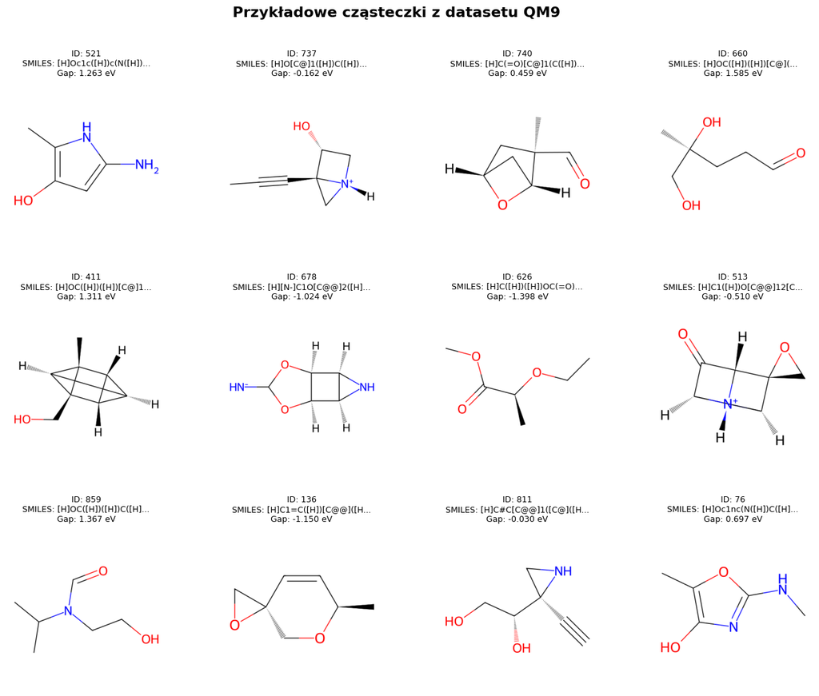

```
======================================================================
CZĄSTECZKI O EKSTREMALNYCH WŁAŚCIWOŚCIACH
======================================================================

🔍 Ekstremalne cząsteczki:
  1. Najwyższy gap: 4.752 eV
     SMILES: [H]C#C[C@@]1(C([H])([H])C([H])=O)N([H])[C@]1([H])C([H])([H])[H]
  2. Najniższy gap: -2.537 eV
     SMILES: [H]C1=C([H])c2c(oc([H])c2[H])C1=O
  3. Najwyższy dipole: 4.349 D
     SMILES: [H]C1=C([H])c2c(oc([H])c2[H])C1=O
  4. Najniższy dipole: -1.694 D
     SMILES: [H]C#C[C@@]1(C([H])([H])C([H])=O)N([H])[C@]1([H])C([H])([H])[H]

✅ Zapisano: qm9_extreme_molecules.png
```

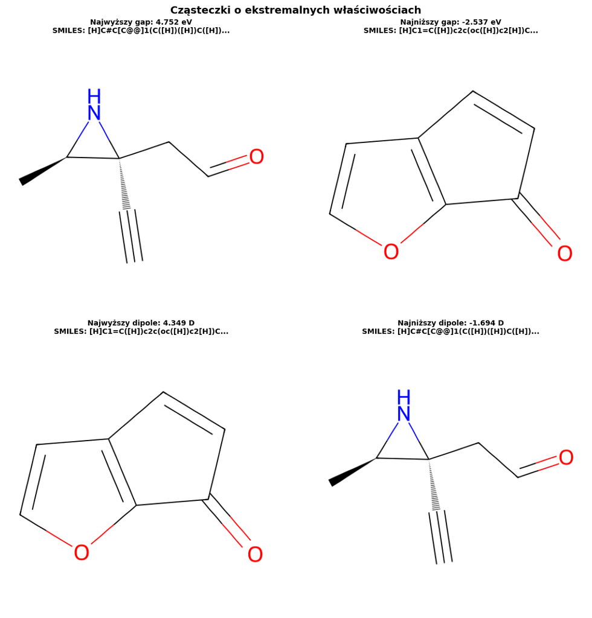

```
======================================================================
CZĄSTECZKI WEDŁUG ROZMIARU
======================================================================

📏 Cząsteczki według rozmiaru:
  • Najmniejsza (4 atomów): [H]N([H])C(=O)C([H])([H])[H]
  • Średnia (9 atomów): [H]O[C@@]12C([H])([H])O[C@]1([H])[C@]2([H])[C@]([H])(O[H])C([H])([H])[H]
  • Największa (11 atomów): [H]/N=C(/C(=O)N(/C([H])=N/[H])C([H])([H])[H])N([H])[H]

✅ Zapisano: qm9_size_comparison.png
```

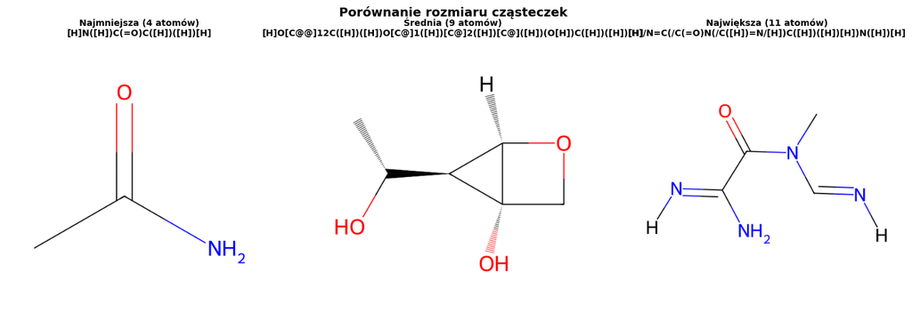

```
======================================================================
✅ WIZUALIZACJE ZAKOŃCZONE!
   Wygenerowano 3 pliki PNG z strukturami molekularnymi
======================================================================
```

# brakujace wartosaci i duplikaty

```
✔️ Brak brakujących wartości w zbiorze danych.
✔️ Brak duplikatów w zbiorze danych.
```

# teraz czas na sprawdzenie czy mamy jkaieś odstające wartosci i wyrysoanie box plotów

```
📊 Sprawdzenie wartości odstających w kolumnach numerycznych:

dipole_moment: 10 wartości odstających
polarizability: 33 wartości odstających
HOMO: 68 wartości odstających
LUMO: 0 wartości odstających
gap: 2 wartości odstających
electronic_spatial_extent: 70 wartości odstających
zpve: 3 wartości odstających
U0: 17 wartości odstających
U: 25 wartości odstających
H: 25 wartości odstających
G: 25 wartości odstających
Cv: 25 wartości odstających
num_atoms: 195 wartości odstających
```

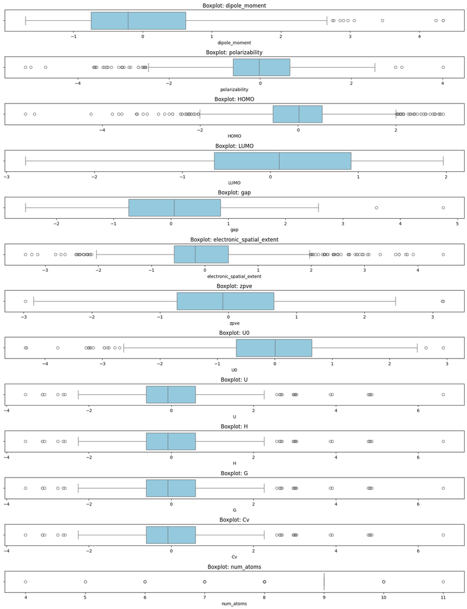

# wzory kilku czasteczek o wartosciach odstajacych

```
Index(['dipole_moment', 'polarizability', 'HOMO', 'LUMO', 'gap',
       'electronic_spatial_extent', 'zpve', 'U0', 'U', 'H', 'G', 'Cv',
       'SMILES', 'dataset_split', 'num_atoms'],
      dtype='object')
```

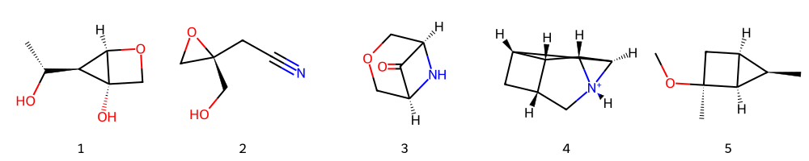

# kolejny punkt

## teraz czas na korelacja

```
======================================================================
ANALIZA KORELACJI - WŁAŚCIWOŚCI QM9
======================================================================

📊 Analizowane właściwości (12):
   1. dipole_moment
   2. polarizability
   3. HOMO
   4. LUMO
   5. gap
   6. electronic_spatial_extent
   7. zpve
   8. U0
   9. U
  10. H
  11. G
  12. Cv

======================================================================
1. PEŁNA MACIERZ KORELACJI PEARSONA
======================================================================

✓ Macierz korelacji obliczona: (12, 12)
```

```
✅ Zapisano: qm9_correlation_full.png
```

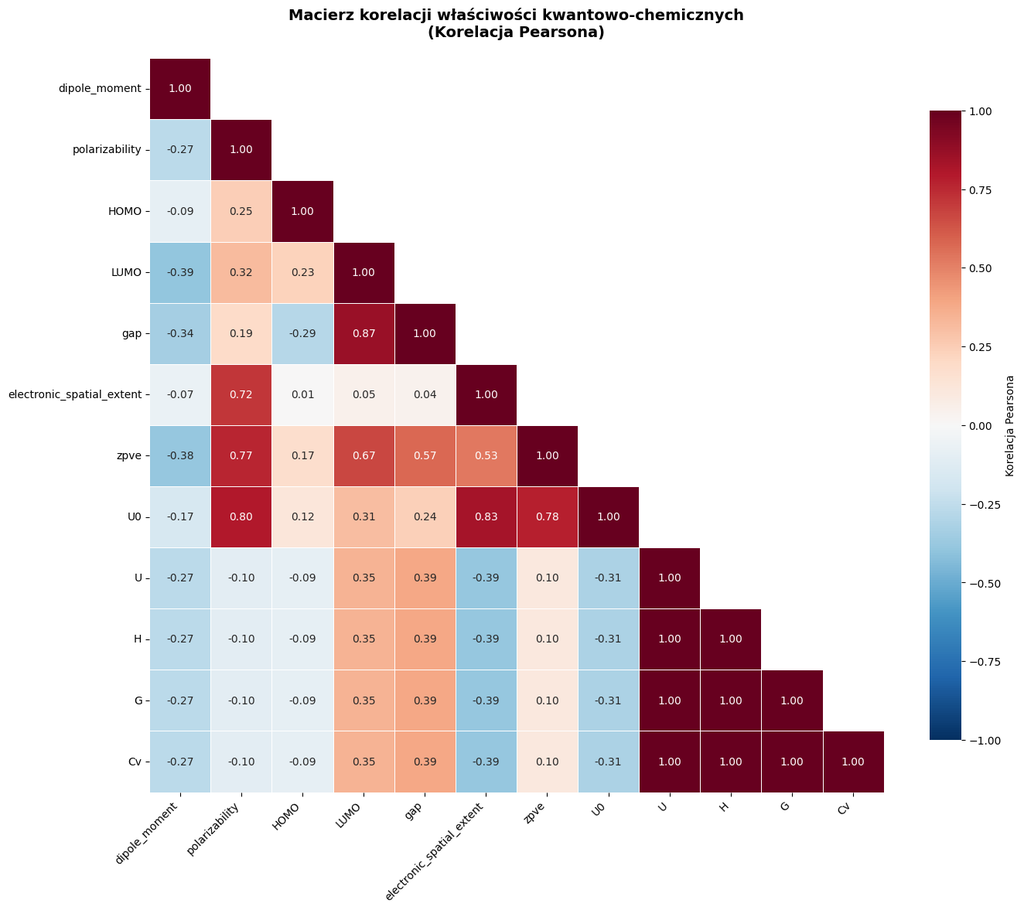

```
======================================================================
2. TOP 15 NAJSILNIEJSZYCH KORELACJI
======================================================================

🔝 TOP 15 najsilniejszych korelacji (wartość bezwzględna):
----------------------------------------------------------------------
  H                         ↔ G                          r = +1.0000
  U                         ↔ H                          r = +1.0000
  U                         ↔ G                          r = +1.0000
  U                         ↔ Cv                         r = +1.0000
  H                         ↔ Cv                         r = +1.0000
  G                         ↔ Cv                         r = +1.0000
  LUMO                      ↔ gap                        r = +0.8670
  electronic_spatial_extent ↔ U0                         r = +0.8288
  polarizability            ↔ U0                         r = +0.7982
  zpve                      ↔ U0                         r = +0.7758
  polarizability            ↔ zpve                       r = +0.7655
  polarizability            ↔ electronic_spatial_extent  r = +0.7170
  LUMO                      ↔ zpve                       r = +0.6705
  gap                       ↔ zpve                       r = +0.5705
  electronic_spatial_extent ↔ zpve                       r = +0.5284

✅ Zapisano: qm9_top_correlations.png
```

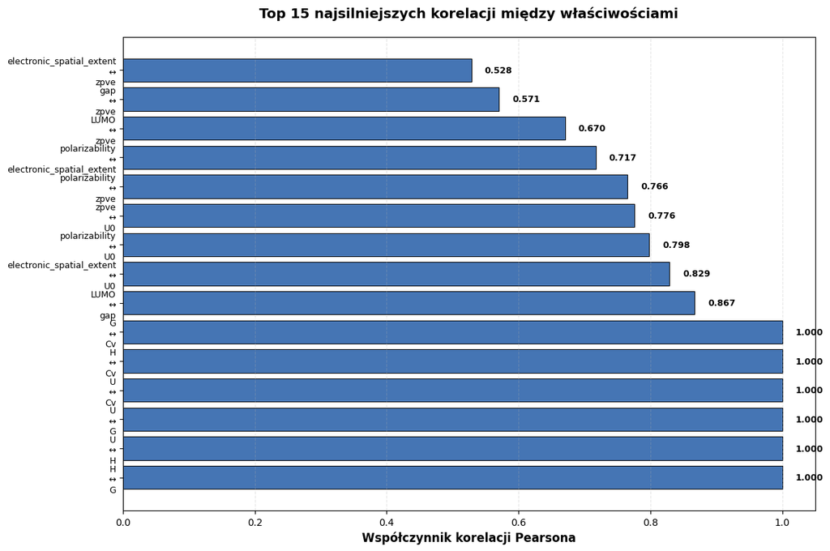

```
======================================================================
3. ANALIZA HOMO-LUMO-GAP
======================================================================

📊 Korelacje z HOMO-LUMO gap:
----------------------------------------------------------------------
  LUMO                            r = +0.8670
  zpve                            r = +0.5705
  G                               r = +0.3873
  H                               r = +0.3873
  U                               r = +0.3873
  Cv                              r = +0.3873
  U0                              r = +0.2404
  polarizability                  r = +0.1883
  electronic_spatial_extent       r = +0.0438
  HOMO                            r = -0.2878
  dipole_moment                   r = -0.3407

✅ Zapisano: qm9_homo_lumo_gap.png
```

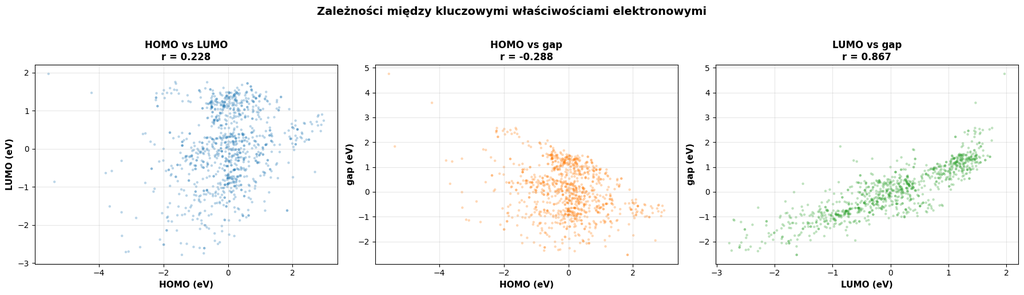

```
======================================================================
4. PAIRPLOT - KLUCZOWE WŁAŚCIWOŚCI
======================================================================

📈 Tworzenie pairplot dla 5 właściwości...
   Używam 1000 próbek dla szybszej wizualizacji
✅ Zapisano: qm9_pairplot.png
```

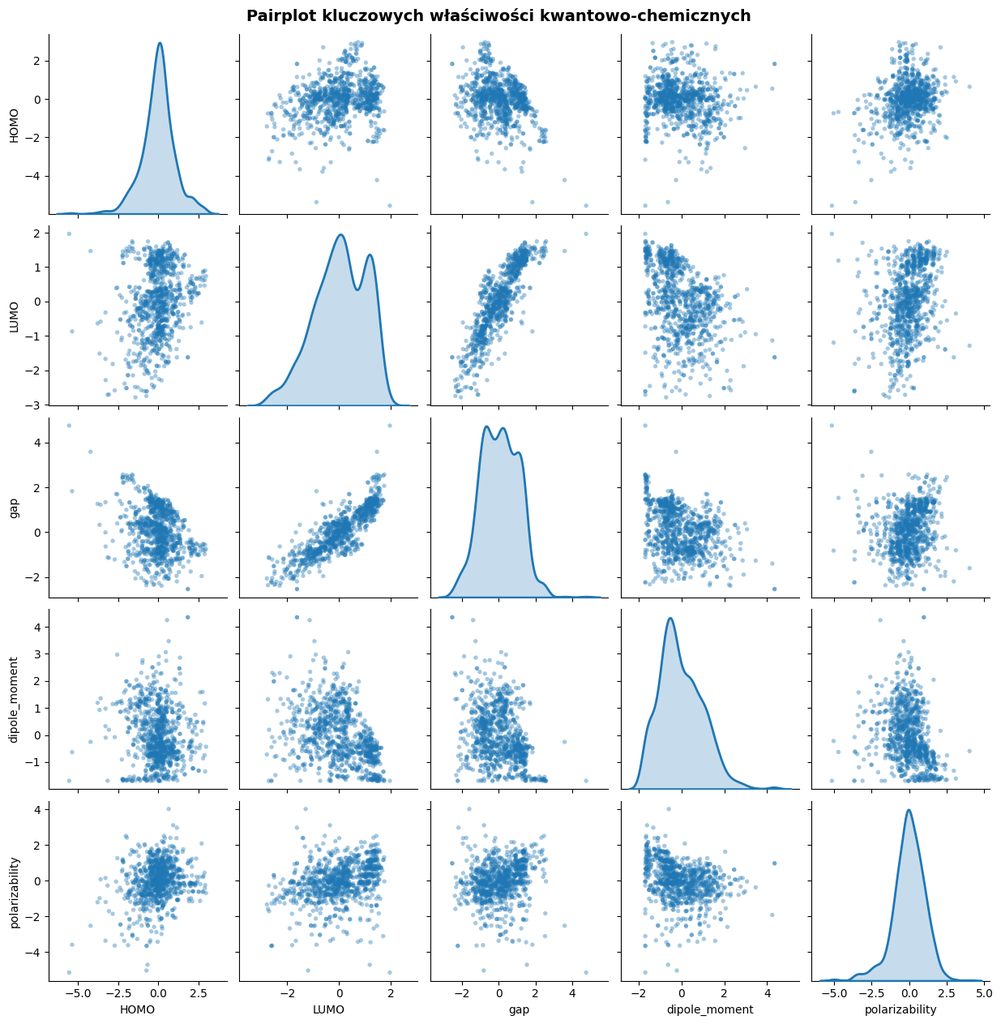

```
======================================================================
5. PORÓWNANIE KORELACJI PEARSONA vs SPEARMANA
======================================================================

📊 Największe różnice między Pearson a Spearman (nieliniowości):
----------------------------------------------------------------------
  polarizability       ↔ H
    Pearson: -0.1031  |  Spearman: +0.1497  |  Diff: 0.2528
  polarizability       ↔ G
    Pearson: -0.1031  |  Spearman: +0.1497  |  Diff: 0.2528
  polarizability       ↔ U
    Pearson: -0.1031  |  Spearman: +0.1496  |  Diff: 0.2527
  polarizability       ↔ Cv
    Pearson: -0.1031  |  Spearman: +0.1495  |  Diff: 0.2526
  U0                   ↔ H
    Pearson: -0.3127  |  Spearman: -0.1948  |  Diff: 0.1179
  U0                   ↔ G
    Pearson: -0.3127  |  Spearman: -0.1948  |  Diff: 0.1179
  U0                   ↔ U
    Pearson: -0.3127  |  Spearman: -0.1950  |  Diff: 0.1177
  U0                   ↔ Cv
    Pearson: -0.3128  |  Spearman: -0.1953  |  Diff: 0.1175
  polarizability       ↔ gap
    Pearson: +0.1883  |  Spearman: +0.2940  |  Diff: 0.1057
  HOMO                 ↔ U0
    Pearson: +0.1213  |  Spearman: +0.0184  |  Diff: 0.1028

======================================================================
6. PODSUMOWANIE ANALIZY KORELACJI
======================================================================

📊 STATYSTYKI KORELACJI:

• Liczba analizowanych właściwości: 12
• Liczba par korelacji: 66

• Najsilniejsza korelacja dodatnia:
  H ↔ G
  r = 1.0000

• Najsilniejsza korelacja ujemna:
  dipole_moment ↔ LUMO
  r = -0.3941

• Silne korelacje (|r| > 0.7): 12
• Średnie korelacje (0.3 < |r| < 0.7): 24
• Słabe korelacje (|r| < 0.3): 30

======================================================================
✅ ANALIZA KORELACJI ZAKOŃCZONA!
   Wygenerowano 4 pliki PNG z wizualizacjami
======================================================================
```

## 🔝 TOP 15 NAJSILNIEJSZYCH KORELACJI

Poniżej przedstawiono 15 par właściwości z najsilniejszymi korelacjami w datasecie QM9:

### **Korelacje perfekcyjne (r = 1.00)**

Te właściwości są ze sobą matematycznie związane poprzez definicje termodynamiczne:

- **H ↔ G** → r = +1.0000 (Entalpia vs Energia Gibbsa)
- **U ↔ H** → r = +1.0000 (Energia wewnętrzna vs Entalpia)
- **U ↔ G** → r = +1.0000 (Energia wewnętrzna vs Energia Gibbsa)
- **U ↔ Cv** → r = +1.0000 (Energia wewnętrzna vs Pojemność cieplna)
- **H ↔ Cv** → r = +1.0000 (Entalpia vs Pojemność cieplna)
- **G ↔ Cv** → r = +1.0000 (Energia Gibbsa vs Pojemność cieplna)

> ⚠️ **Uwaga**: Te 6 par wykazują korelację 1.0, co sugeruje, że są ze sobą liniowo zależne. W modelowaniu ML należy rozważyć usunięcie redundantnych zmiennych, aby uniknąć multikolinearności.

### **Korelacje bardzo silne (r > 0.70)**

- **LUMO ↔ gap** → r = +0.8670  
  *LUMO energy jest głównym składnikiem HOMO-LUMO gap*
- **electronic_spatial_extent ↔ U0** → r = +0.8288  
  *Większe cząsteczki mają wyższą energię wewnętrzną*
- **polarizability ↔ U0** → r = +0.7982  
  *Polaryzowalność rośnie z rozmiarem molekuły*
- **zpve ↔ U0** → r = +0.7758  
  *Energia drgań punktu zerowego koreluje z całkowitą energią*
- **polarizability ↔ zpve** → r = +0.7655  
  *Obie właściwości zależą od rozmiaru molekuły*
- **polarizability ↔ electronic_spatial_extent** → r = +0.7170  
  *Bezpośrednia zależność od objętości elektronowej*

### **Korelacje silne (0.50 < r < 0.70)**

- **LUMO ↔ zpve** → r = +0.6705
- **gap ↔ zpve** → r = +0.5705
- **electronic_spatial_extent ↔ zpve** → r = +0.5284

### 💡 **Kluczowe wnioski:**

1. **Właściwości termodynamiczne** (U, H, G, Cv) są ze sobą idealnie skorelowane - wystarczy jedna z nich w modelach predykcyjnych
2. **LUMO i gap** są silnie powiązane - gap częściowo zależy od LUMO
3. **Rozmiar molekuły** (mierzony przez polarizability i electronic_spatial_extent) silnie wpływa na właściwości energetyczne
4. **Brak silnych korelacji ujemnych** w top 15 - większość zależności jest dodatnia

# Walidacja SMILES - ile błędnych struktur, dlaczego

```
======================================================================
WALIDACJA STRUKTUR SMILES - QM9 DATASET
======================================================================

📋 ETAP 1: PODSTAWOWA WALIDACJA
----------------------------------------------------------------------
Walidacja struktur SMILES...

✅ Poprawne SMILES: 1,000 (100.00%)
❌ Niepoprawne SMILES: 0 (0.00%)

✅ WSZYSTKIE SMILES SĄ POPRAWNE! Dataset QM9 ma 100% validację.

======================================================================
🧪 ANALIZA SKŁADU CHEMICZNEGO
======================================================================

Analizuję skład atomowy cząsteczek...

📊 Typy atomów występujące w datasecie (5):
  • C    występuje w  1,000 cząsteczkach (100.00%)
  • O    występuje w    843 cząsteczkach (84.30%)
  • N    występuje w    622 cząsteczkach (62.20%)
  • H    występuje w     16 cząsteczkach ( 1.60%)
  • F    występuje w     14 cząsteczkach ( 1.40%)

📈 Statystyki liczby atomów:
                 C            N            O            H            F
count  1000.000000  1000.000000  1000.000000  1000.000000  1000.000000
mean      6.251000     1.093000     1.392000     0.017000     0.020000
std       1.282046     1.138265     0.875844     0.136857     0.188774
min       2.000000     0.000000     0.000000     0.000000     0.000000
25%       5.000000     0.000000     1.000000     0.000000     0.000000
50%       6.000000     1.000000     1.000000     0.000000     0.000000
75%       7.000000     2.000000     2.000000     0.000000     0.000000
max       9.000000     6.000000     4.000000     2.000000     3.000000

======================================================================
📊 WIZUALIZACJA SKŁADU ATOMOWEGO
======================================================================
✅ Zapisano: qm9_atomic_composition.png
```

```
======================================================================
⚗️ OBLICZANIE DESKRYPTORÓW MOLEKULARNYCH
======================================================================
Obliczam deskryptory RDKit dla poprawnych struktur...

⚠️  BRAK POPRAWNYCH STRUKTUR DO ANALIZY!
   Wszystkie SMILES są niepoprawne lub nie można obliczyć deskryptorów.

⚠️  Brak danych do wizualizacji właściwości molekularnych

======================================================================
✅ WALIDACJA I ANALIZA SMILES ZAKOŃCZONA!
======================================================================
```

```
======================================================================
🔍 DEBUGGING - ANALIZA KOLUMNY SMILES
======================================================================

1️⃣ Kolumny w DataFrame:
['dipole_moment', 'polarizability', 'HOMO', 'LUMO', 'gap', 'electronic_spatial_extent', 'zpve', 'U0', 'U', 'H', 'G', 'Cv', 'SMILES', 'dataset_split', 'num_atoms', 'is_valid', 'error_type']

2️⃣ Czy 'SMILES' w kolumnach? True

3️⃣ Pierwsze 10 wartości w kolumnie SMILES:
   1. [H]C([H])([H])C([H])([H])[N@@H+]1C([H])([H])[C@]1(C([H])([H])[H])C([H])([H])C([H])([H])C([H])([H])[H]
   2. [H]O[C@@]12C([H])([H])O[C@]1([H])[C@]2([H])[C@]([H])(O[H])C([H])([H])[H]
   3. [H]C1([H])C([H])([H])[C@]2([H])[C@@]1([H])[C@]1([H])OC([H])([H])[C@@]12C([H])([H])[H]
   4. [H]OC([H])([H])[C@]1(C([H])([H])C#N)OC1([H])[H]
   5. [H]N1[C@]2([H])C(=O)[C@@]1([H])C([H])([H])OC2([H])[H]
   6. [H][N-]C1OC([H])([H])[C@]12[N@@H+]1C([H])([H])[C@]1([H])C2([H])[H]
   7. [H]N([H])C1[NH2+][C@]2([H])C([H])([H])[C@]2(C([H])([H])C([H])([H])[H])O1
   8. [H]C1([H])[N@@H+]2[C@@]3([H])[C@]2([H])[C@@]2([H])C([H])([H])[C@]1([H])[C@@]32[H]
   9. [H]C([H])([H])O[C@@]1(C([H])([H])[H])C([H])([H])[C@@]2([H])[C@@]([H])(C([H])([H])[H])[C@@]12[H]
  10. [H]C(=O)c1c([H])c(N([H])[H])nn1[H]

4️⃣ Typ danych kolumny SMILES: object

5️⃣ Statystyki długości SMILES:
  Min: 13
  Max: 101
  Średnia: 62.8

6️⃣ Puste/NaN wartości: 0

7️⃣ Test walidacji pojedynczego SMILES:
  SMILES: [H]C([H])([H])C([H])([H])[N@@H+]1C([H])([H])[C@]1(C([H])([H])[H])C([H])([H])C([H])([H])C([H])([H])[H]
  Typ: <class 'str'>
  ✅ RDKit sparsował poprawnie
  Liczba atomów: 9

======================================================================
```

SMILES są poprawne, ale mają jawne atomy wodoru [H] i sterochemię [C@], [C@@] - to są bardzo szczegółowe SMILES z QM9! Problem jest w poprzednim kodzie - prawdopodobnie kolumny is_valid i error_type już istnieją z poprzedniego uruchomienia i nadpisują nowe wyniki. Rozwiązanie: Usuńmy te kolumny przed walidacją:

```
======================================================================
WALIDACJA STRUKTUR SMILES - QM9 DATASET
======================================================================

📋 ETAP 1: PODSTAWOWA WALIDACJA
----------------------------------------------------------------------
Walidacja struktur SMILES...
Przykładowe SMILES do walidacji:
['[H]C([H])([H])C([H])([H])[N@@H+]1C([H])([H])[C@]1(C([H])([H])[H])C([H])([H])C([H])([H])C([H])([H])[H]', '[H]O[C@@]12C([H])([H])O[C@]1([H])[C@]2([H])[C@]([H])(O[H])C([H])([H])[H]', '[H]C1([H])C([H])([H])[C@]2([H])[C@@]1([H])[C@]1([H])OC([H])([H])[C@@]12C([H])([H])[H]', '[H]OC([H])([H])[C@]1(C([H])(…

✅ Poprawne SMILES: 1,000 (100.00%)
❌ Niepoprawne SMILES: 0 (0.00%)

✓ Przykłady POPRAWNYCH SMILES:
['[H]C([H])([H])C([H])([H])[N@@H+]1C([H])([H])[C@]1(C([H])([H])[H])C([H])([H])C([H])([H])C([H])([H])[H]', '[H]O[C@@]12C([H])([H])O[C@]1([H])[C@]2([H])[C@]([H])(O[H])C([H])([H])[H]', '[H]C1([H])C([H])([H])[C@]2([H])[C@@]1([H])[C@]1([H])OC([H])([H])[C@@]12C([H])([H])[H]']

✅ WSZYSTKIE SMILES SĄ POPRAWNE! Dataset QM9 ma 100% validację.

======================================================================
🧪 ANALIZA SKŁADU CHEMICZNEGO
======================================================================

Analizuję skład atomowy cząsteczek...

📊 Typy atomów występujące w datasecie (5):
  • C    występuje w  1,000 cząsteczkach (100.00%)
  • O    występuje w    843 cząsteczkach (84.30%)
  • N    występuje w    622 cząsteczkach (62.20%)
  • H    występuje w     16 cząsteczkach ( 1.60%)
  • F    występuje w     14 cząsteczkach ( 1.40%)

📈 Statystyki liczby atomów:
                 C            N            O            H            F
count  1000.000000  1000.000000  1000.000000  1000.000000  1000.000000
mean      6.251000     1.093000     1.392000     0.017000     0.020000
std       1.282046     1.138265     0.875844     0.136857     0.188774
min       2.000000     0.000000     0.000000     0.000000     0.000000
25%       5.000000     0.000000     1.000000     0.000000     0.000000
50%       6.000000     1.000000     1.000000     0.000000     0.000000
75%       7.000000     2.000000     2.000000     0.000000     0.000000
max       9.000000     6.000000     4.000000     2.000000     3.000000

======================================================================
📊 WIZUALIZACJA SKŁADU ATOMOWEGO
======================================================================
✅ Zapisano: qm9_atomic_composition.png
```

```
======================================================================
⚗️ OBLICZANIE DESKRYPTORÓW MOLEKULARNYCH
======================================================================
Obliczam deskryptory RDKit dla poprawnych struktur...

⚠️  BRAK POPRAWNYCH STRUKTUR DO ANALIZY!
   Wszystkie SMILES są niepoprawne lub nie można obliczyć deskryptorów.

⚠️  Brak danych do wizualizacji właściwości molekularnych

======================================================================
✅ WALIDACJA I ANALIZA SMILES ZAKOŃCZONA!
======================================================================
```

```
======================================================================
WALIDACJA STRUKTUR SMILES - QM9 DATASET
======================================================================

📋 ETAP 1: PODSTAWOWA WALIDACJA
----------------------------------------------------------------------
Walidacja struktur SMILES...

✅ Poprawne SMILES: 1,000 (100.00%)
❌ Niepoprawne SMILES: 0 (0.00%)

✓ Kontynuuję analizę 1,000 poprawnych struktur...

======================================================================
🧪 ANALIZA SKŁADU CHEMICZNEGO
======================================================================

Analizuję skład atomowy cząsteczek...

📊 Typy atomów występujące w datasecie (5):
  • C    występuje w  1,000 cząsteczkach (100.00%)
  • O    występuje w    843 cząsteczkach (84.30%)
  • N    występuje w    622 cząsteczkach (62.20%)
  • H    występuje w     16 cząsteczkach ( 1.60%)
  • F    występuje w     14 cząsteczkach ( 1.40%)

📈 Statystyki liczby atomów:
                 C            N            O            H            F
count  1000.000000  1000.000000  1000.000000  1000.000000  1000.000000
mean      6.251000     1.093000     1.392000     0.017000     0.020000
std       1.282046     1.138265     0.875844     0.136857     0.188774
min       2.000000     0.000000     0.000000     0.000000     0.000000
25%       5.000000     0.000000     1.000000     0.000000     0.000000
50%       6.000000     1.000000     1.000000     0.000000     0.000000
75%       7.000000     2.000000     2.000000     0.000000     0.000000
max       9.000000     6.000000     4.000000     2.000000     3.000000

======================================================================
📊 WIZUALIZACJA SKŁADU ATOMOWEGO
======================================================================
✅ Zapisano: qm9_atomic_composition.png
```

```
======================================================================
⚗️ OBLICZANIE DESKRYPTORÓW MOLEKULARNYCH
======================================================================
Obliczam deskryptory RDKit dla poprawnych struktur...
✅ Obliczono 0 deskryptorów dla 1000 struktur

📊 Statystyki deskryptorów molekularnych:
```

[output not shown]

# Rozkład train/valid/test - czy zbalansowany

```
======================================================================
ANALIZA PODZIAŁU DATASETU - TRAIN/VALID/TEST
======================================================================

📊 ETAP 1: ROZKŁAD DANYCH WEDŁUG ZBIORÓW
----------------------------------------------------------------------

📈 Liczebność zbiorów:
  • test  :      91 próbek ( 9.10%)
  • train :     813 próbek (81.30%)
  • valid :      96 próbek ( 9.60%)

  RAZEM:      1,000 próbek (100.00%)

======================================================================
📊 WIZUALIZACJA PODZIAŁU
======================================================================
✅ Zapisano: qm9_dataset_split.png
```

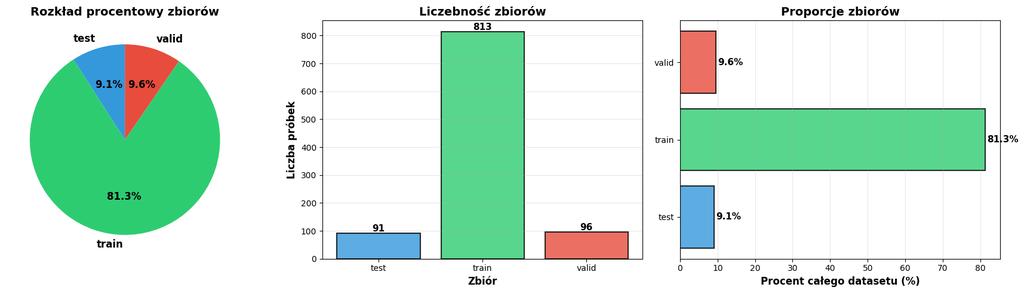

```
======================================================================
🔬 ANALIZA BALANSU WŁAŚCIWOŚCI KWANTOWYCH
======================================================================

📊 Porównanie średnich wartości właściwości między zbiorami:
----------------------------------------------------------------------

HOMO
  Train:    -0.0224  |  Valid:    -0.0890  |  Test:    -0.0519
  Max różnica: 122.23%

LUMO
  Train:     0.0727  |  Valid:    -0.1290  |  Test:    -0.1003
  Max różnica: 386.37%

gap
  Train:     0.0839  |  Valid:    -0.0843  |  Test:    -0.0742
  Max różnica: 676.65%

dipole_moment
  Train:    -0.0299  |  Valid:    -0.0693  |  Test:    -0.0120
  Max różnica: 154.55%

polarizability
  Train:    -0.0297  |  Valid:    -0.0061  |  Test:    -0.0796
  Max różnica: 191.28%

U0
  Train:    -0.0125  |  Valid:    -0.0063  |  Test:    -0.0707
  Max różnica: 215.82%

H
  Train:     0.0289  |  Valid:     0.1364  |  Test:    -0.0878
  Max różnica: 867.44%

G
  Train:     0.0289  |  Valid:     0.1364  |  Test:    -0.0878
  Max różnica: 867.44%

======================================================================
📋 OCENA BALANSU ZBIORÓW
======================================================================

✓ Maksymalna różnica między zbiorami: 867.44%

🔴 SŁABY BALANS
  Znaczące różnice między zbiorami

======================================================================
📊 WIZUALIZACJA ROZKŁADÓW KLUCZOWYCH WŁAŚCIWOŚCI
======================================================================
✅ Zapisano: qm9_split_distributions.png
```

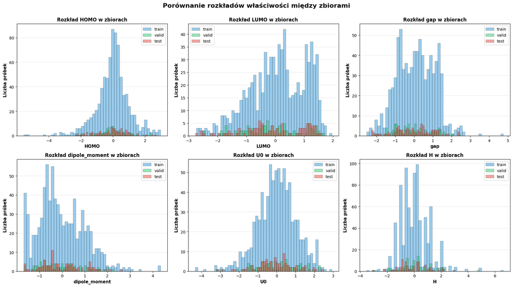

```
======================================================================
📦 BOXPLOTY - PORÓWNANIE MEDIANOWE
======================================================================
```

```
✅ Zapisano: qm9_split_boxplots.png
```

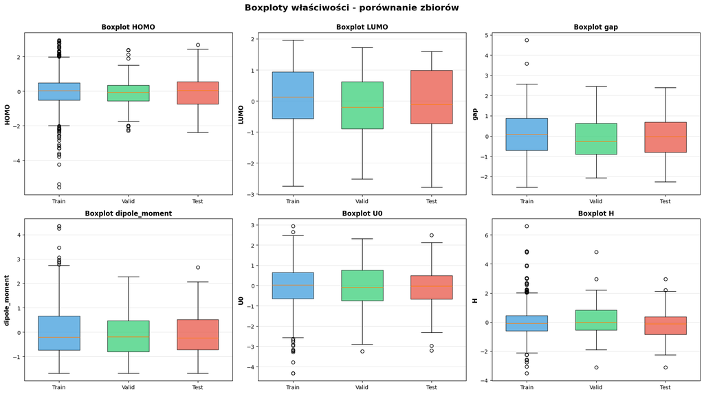

```
======================================================================
📊 PORÓWNANIE STATYSTYK OPISOWYCH
======================================================================

Odchylenia standardowe (im bardziej podobne, tym lepszy balans):
----------------------------------------------------------------------

HOMO
  Train:     1.0495  |  Valid:     0.9226  |  Test:     0.9963
  Różnica: 12.09%

LUMO
  Train:     0.9760  |  Valid:     1.0129  |  Test:     1.1192
  Różnica: 12.80%

gap
  Train:     1.0070  |  Valid:     0.9814  |  Test:     1.0664
  Różnica: 7.97%

dipole_moment
  Train:     1.0284  |  Valid:     0.9200  |  Test:     0.9418
  Różnica: 10.55%

polarizability
  Train:     1.0579  |  Valid:     1.1738  |  Test:     1.0389
  Różnica: 11.50%

U0
  Train:     1.0377  |  Valid:     1.1266  |  Test:     1.0621
  Różnica: 7.89%

H
  Train:     1.0520  |  Valid:     1.1977  |  Test:     1.0812
  Różnica: 12.17%

G
  Train:     1.0520  |  Valid:     1.1977  |  Test:     1.0812
  Różnica: 12.17%

======================================================================
```

[output cut: 10 more lines]

```
  • Maksymalna różnica średnich: 867.44%
  • Właściwości z dobrym balansem: 0/8

✅ WNIOSKI:
  • Podział ma lekką nierówność liczebności
  • Niektóre właściwości mogą różnić się między zbiorami
  • Rozważ dodatkowe sprawdzenie podziału

💡 REKOMENDACJE:
  • Rozważ stratified split dla krytycznych właściwości
  • Monitoruj metryki na wszystkich zbiorach podczas treningu

======================================================================
✅ ANALIZA PODZIAŁU ZAKOŃCZONA!
======================================================================
```

### 3. ANALIZA SKŁADU CHEMICZNEGO 🧪

- Rozkład atomów (H, C, N, O, F) - ile każdego typu
- Masa molowa - rozkład, median, percentyle
- Liczba atomów ciężkich - histogram, statystyki
- Liczba atomów wodoru - analiza
- Wzory sumaryczne - najczęstsze składy

```
======================================================================
ANALIZA SKŁADU CHEMICZNEGO - QM9 DATASET
======================================================================

🧪 ETAP 1: ROZKŁAD ATOMÓW W DATASECIE
----------------------------------------------------------------------
Analizuję skład atomowy cząsteczek...

📊 Statystyki rozkładu atomów:
----------------------------------------------------------------------
                 H            C            N            O            F
count  1000.000000  1000.000000  1000.000000  1000.000000  1000.000000
mean      9.322000     6.251000     1.093000     1.392000     0.020000
std       3.103215     1.282046     1.138265     0.875844     0.188774
min       1.000000     2.000000     0.000000     0.000000     0.000000
25%       7.000000     5.000000     0.000000     1.000000     0.000000
50%       9.000000     6.000000     1.000000     1.000000     0.000000
75%      12.000000     7.000000     2.000000     2.000000     0.000000
max      18.000000     9.000000     6.000000     4.000000     3.000000

📈 Całkowita liczba atomów w datasecie:
  • H: 9,322 atomów | Średnio 9.32 na cząsteczkę
  • C: 6,251 atomów | Średnio 6.25 na cząsteczkę
  • N: 1,093 atomów | Średnio 1.09 na cząsteczkę
  • O: 1,392 atomów | Średnio 1.39 na cząsteczkę
  • F: 20 atomów | Średnio 0.02 na cząsteczkę

======================================================================
📊 WIZUALIZACJA ROZKŁADU ATOMÓW
======================================================================
✅ Zapisano: qm9_atom_distribution.png
```

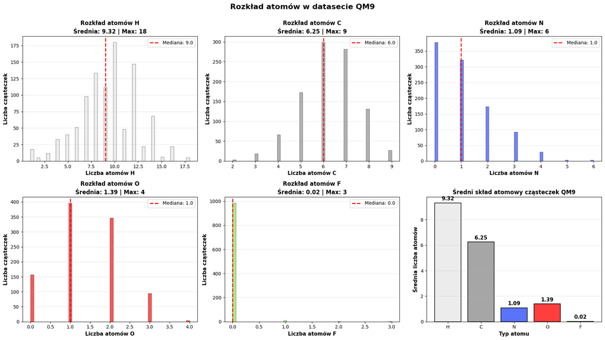

```
======================================================================
⚖️  ANALIZA MASY MOLOWEJ
======================================================================

📊 Statystyki masy molowej:
  • Średnia:    122.53 g/mol
  • Mediana:    125.13 g/mol
  • Odch. std:  8.67 g/mol
  • Min:        59.07 g/mol
  • Max:        142.12 g/mol

📈 Percentyle masy molowej:
  • 10%:  112.11 g/mol
  • 25%:  121.10 g/mol
  • 50%:  125.13 g/mol
  • 75%:  128.13 g/mol
  • 90%:  130.08 g/mol
  • 95%:  131.13 g/mol
  • 99%:  132.20 g/mol
```

```
✅ Zapisano: qm9_molecular_weight.png
```

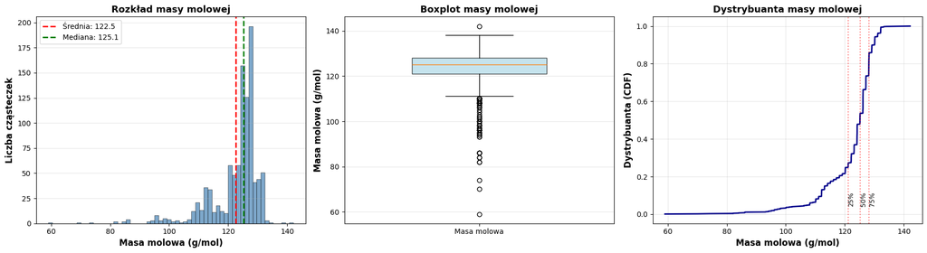

```
======================================================================
🔬 ANALIZA ATOMÓW CIĘŻKICH (non-H)
======================================================================

📊 Statystyki atomów ciężkich:
  • Średnia:   8.76 atomów
  • Mediana:   9 atomów
  • Min:       4 atomów
  • Max:       9 atomów
  • Limit QM9: 9 atomów ciężkich

📈 Rozkład liczby atomów ciężkich:
   4 atomów:      1 cząsteczek ( 0.10%)
   5 atomów:      2 cząsteczek ( 0.20%)
   6 atomów:      8 cząsteczek ( 0.80%)
   7 atomów:     30 cząsteczek ( 3.00%) █
   8 atomów:    147 cząsteczek (14.70%) ███████
   9 atomów:    812 cząsteczek (81.20%) ████████████████████████████████████████

✅ Zapisano: qm9_heavy_atoms.png
```

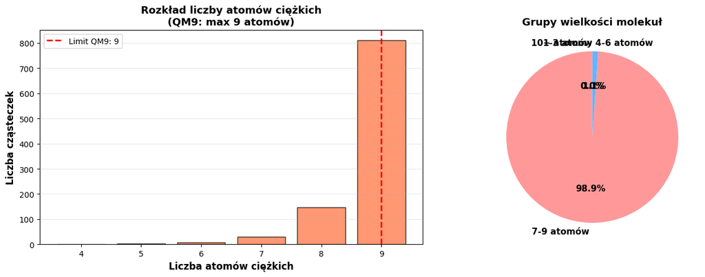

```
======================================================================
🧬 WZORY SUMARYCZNE - NAJCZĘSTSZE SKŁADY
======================================================================

🏆 TOP 20 najczęstszych wzorów sumarycznych:
----------------------------------------------------------------------
   1. C7H10O2            52 cząsteczek ( 5.20%)
   2. C6H9NO2            39 cząsteczek ( 3.90%)
   3. C7H12O2            36 cząsteczek ( 3.60%)
   4. C8H12O             35 cząsteczek ( 3.50%)
   5. C7H9NO             25 cząsteczek ( 2.50%)
   6. C6H8O3             23 cząsteczek ( 2.30%)
   7. C8H10O             21 cząsteczek ( 2.10%)
   8. C6H7NO2            19 cząsteczek ( 1.90%)
   9. C7H8O2             19 cząsteczek ( 1.90%)
  10. C7H14NO            18 cząsteczek ( 1.80%)
  11. C6H10N2O           17 cząsteczek ( 1.70%)
  12. C6H10O3            16 cząsteczek ( 1.60%)
  13. C7H12NO            15 cząsteczek ( 1.50%)
  14. C8H14O             14 cząsteczek ( 1.40%)
  15. C6H8N2O            14 cząsteczek ( 1.40%)
  16. C6H11NO2           13 cząsteczek ( 1.30%)
  17. C6H12O3            13 cząsteczek ( 1.30%)
  18. C8H16O             12 cząsteczek ( 1.20%)
  19. C7H7NO             12 cząsteczek ( 1.20%)
  20. C9H14              11 cząsteczek ( 1.10%)

✅ Zapisano: qm9_molecular_formulas.png
```

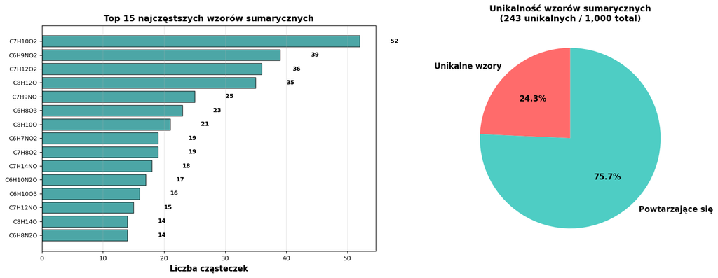

```
======================================================================
📋 PODSUMOWANIE SKŁADU CHEMICZNEGO
======================================================================

🧪 SKŁAD ATOMOWY:
  • Średnia H:  9.32 (wodór)
  • Średnia C:  6.25 (węgiel)
  • Średnia N:  1.09 (azot)
  • Średnia O:  1.39 (tlen)
  • Średnia F:  0.02 (fluor)

⚖️  MASA MOLOWA:
  • Zakres:     59.1 - 142.1 g/mol
  • Średnia:    122.5 g/mol
  • Mediana:    125.1 g/mol

🔬 ATOMY CIĘŻKIE:
  • Zakres:     4 - 9 atomów
  • Średnia:    8.76 atomów
  • Limit QM9:  9 atomów ciężkich (spec datasetu)

🧬 WZORY SUMARYCZNE:
  • Unikalne wzory:           243
  • Całkowita liczba molekuł: 1,000
  • Najczęstszy wzór:         C7H10O2 (52 molekuł)

✅ CHARAKTERYSTYKA DATASETU:
  • QM9 zawiera małe cząsteczki organiczne (max 9 ciężkich atomów)
  • Dominują związki z H, C, N, O, F (jak w specyfikacji)
  • Duża różnorodność strukturalna (243 unikalnych wzorów)
  • Masa molowa typowo poniżej 150 g/mol (small molecules)

======================================================================
✅ ANALIZA SKŁADU CHEMICZNEGO ZAKOŃCZONA!
======================================================================
```

### 4. ANALIZA STRUKTURALNA 🔬

- Liczba wiązań - single, double, triple, aromatic
- Liczba pierścieni - histogram, rozkład 0-3 pierścienie
- Pierścienie aromatyczne vs alifatyczne
- Rotowalne wiązania - flexibility molekuł
- Frakcja sp3 - saturacja vs aromatyczność
- Chiralność - czy są centra chiralne

```
======================================================================
ANALIZA STRUKTURALNA - QM9 DATASET
======================================================================

🔗 ETAP 1: ANALIZA TYPÓW WIĄZAŃ
----------------------------------------------------------------------
Analizuję typy wiązań w cząsteczkach...

📊 Statystyki typów wiązań:
            single       double       triple     aromatic
count  1000.000000  1000.000000  1000.000000  1000.000000
mean      7.502000     0.613000     0.268000     0.974000
std       2.624287     0.749528     0.548157     2.129756
min       0.000000     0.000000     0.000000     0.000000
25%       6.000000     0.000000     0.000000     0.000000
50%       8.000000     0.000000     0.000000     0.000000
75%       9.000000     1.000000     0.000000     0.000000
max      13.000000     3.000000     4.000000    10.000000

📈 Średnia liczba wiązań każdego typu:
  • single    : Średnio 7.50 | Molekuły z tym wiązaniem: 997 (99.7%)
  • double    : Średnio 0.61 | Molekuły z tym wiązaniem: 472 (47.2%)
  • triple    : Średnio 0.27 | Molekuły z tym wiązaniem: 222 (22.2%)
  • aromatic  : Średnio 0.97 | Molekuły z tym wiązaniem: 179 (17.9%)

✅ Zapisano: qm9_bond_types.png
```

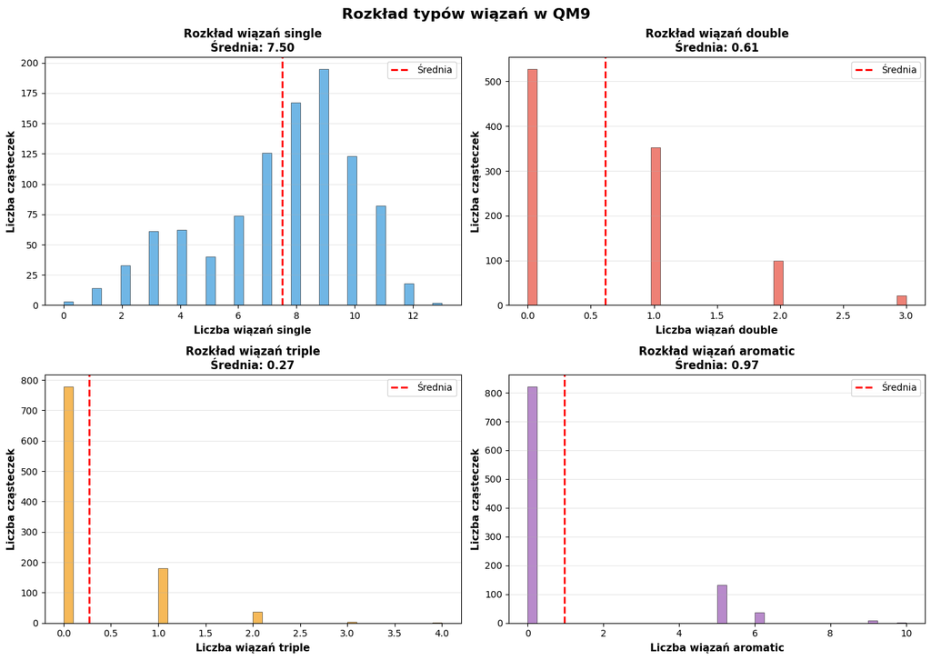

```
======================================================================
⭕ ANALIZA PIERŚCIENI
======================================================================
Analizuję struktury pierścieniowe...

📊 Statystyki pierścieni:
       total_rings  aromatic_rings  aliphatic_rings  saturated_rings  \
count  1000.000000     1000.000000      1000.000000      1000.000000
mean      1.696000        0.189000         1.507000         1.333000
std       1.153653        0.416476         1.282028         1.302231
min       0.000000        0.000000         0.000000         0.000000
25%       1.000000        0.000000         1.000000         0.000000
50%       1.000000        0.000000         1.000000         1.000000
75%       2.000000        0.000000         2.000000         2.000000
max       7.000000        2.000000         7.000000         7.000000

       hetero_rings  aromatic_hetero_rings
count   1000.000000            1000.000000
mean       1.018000               0.188000
std        0.893574               0.415727
min        0.000000               0.000000
25%        0.000000               0.000000
50%        1.000000               0.000000
75%        1.000000               0.000000
max        6.000000               2.000000

📈 Rozkład liczby pierścieni:
  0 pierścieni:     98 cząsteczek ( 9.80%) ███
  1 pierścieni:    420 cząsteczek (42.00%) ██████████████
  2 pierścieni:    271 cząsteczek (27.10%) █████████
  3 pierścieni:    146 cząsteczek (14.60%) ████
  4 pierścieni:     38 cząsteczek ( 3.80%) █
  5 pierścieni:     21 cząsteczek ( 2.10%)
  6 pierścieni:      3 cząsteczek ( 0.30%)
  7 pierścieni:      3 cząsteczek ( 0.30%)

✓ Z pierścieniami:    902 (90.2%)
✓ Bez pierścieni:     98 (9.8%)

✅ Zapisano: qm9_rings_analysis.png
```

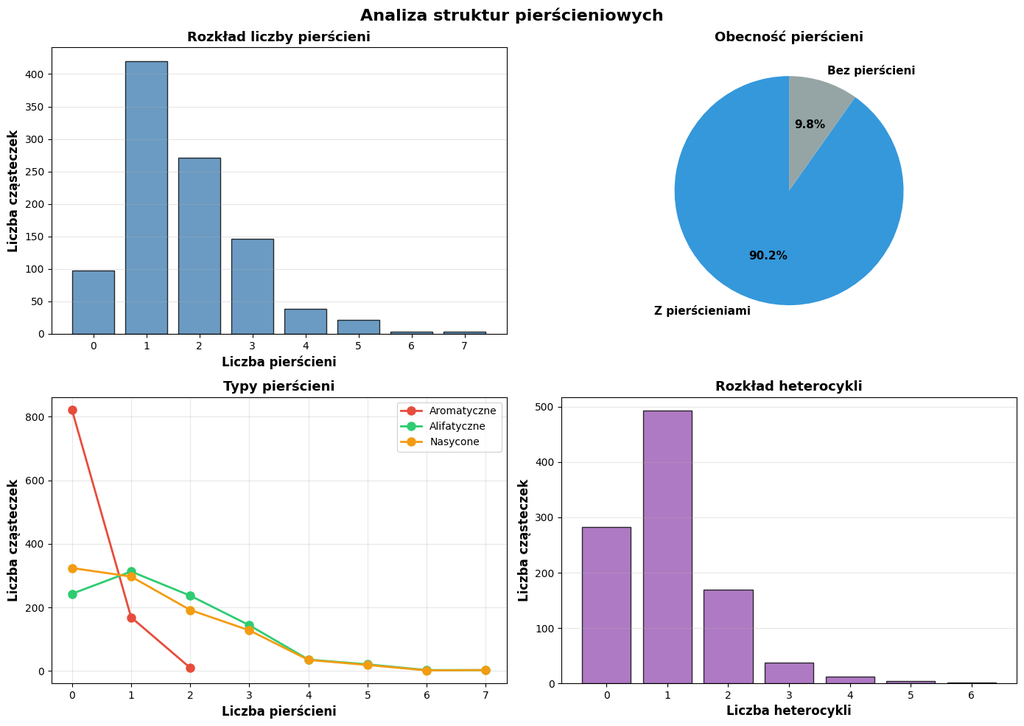

```
======================================================================
🔄 ANALIZA ROTOWALNYCH WIĄZAŃ (FLEXIBILITY)
======================================================================

📊 Statystyki rotowalnych wiązań:
  • Średnia:   0.89 wiązań
  • Mediana:   1 wiązań
  • Max:       5 wiązań
  • Std:       1.07

📈 Rozkład rotowalnych wiązań:
   0 wiązań:    475 cząsteczek (47.50%) ███████████████████████
   1 wiązań:    281 cząsteczek (28.10%) ██████████████
   2 wiązań:    159 cząsteczek (15.90%) ███████
   3 wiązań:     55 cząsteczek ( 5.50%) ██
   4 wiązań:     24 cząsteczek ( 2.40%) █

📋 Klasyfikacja elastyczności:
  • Sztywne (0 wiązań):        475 (47.5%)
  • Semi-elastyczne (1-3):     495 (49.5%)
  • Elastyczne (4+):           30 (3.0%)

✅ Zapisano: qm9_rotatable_bonds.png
```

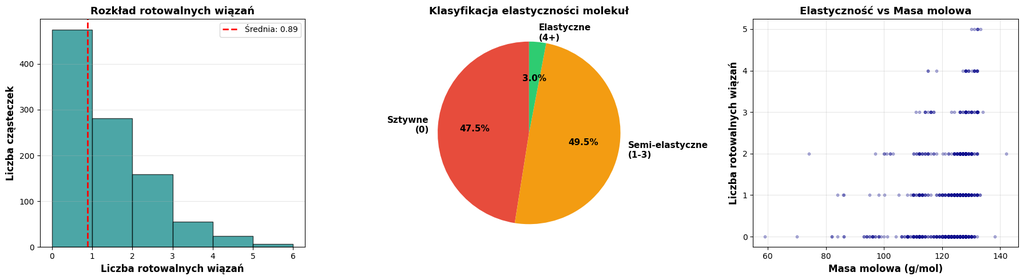

[output not shown]

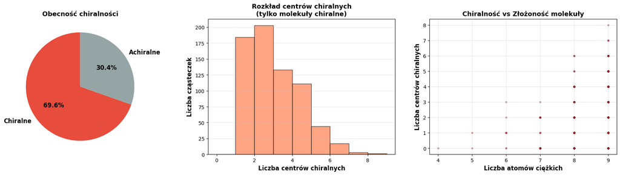

[output not shown]

### 5. WŁAŚCIWOŚCI FIZYKOCHEMICZNE (RDKit) ⚗️

- LogP - lipofilowość, rozkład, outliers
- TPSA - polar surface area, drug-likeness
- HBD/HBA - donory i akceptory wodoru
- Molar Refractivity - objętość molekularna
- Reguła Lipińskiego - ile struktur spełnia Ro5
- Korelacje między deskryptorami - heatmap

```
======================================================================
WŁAŚCIWOŚCI FIZYKOCHEMICZNE - QM9 DATASET
======================================================================

⚗️ ETAP 1: OBLICZANIE DESKRYPTORÓW FIZYKOCHEMICZNYCH
----------------------------------------------------------------------
Obliczam właściwości fizykochemiczne...

✅ Obliczono 7 właściwości dla 1000 molekuł

📊 Statystyki właściwości fizykochemicznych:
              LogP        MolMR         TPSA          HBD          HBA  \
count  1000.000000  1000.000000  1000.000000  1000.000000  1000.000000
mean      0.104381    31.821830    37.802210     0.972000     2.053000
std       1.173836     3.606108    21.399043     0.889948     1.093337
min      -3.467400    14.868400     0.000000     0.000000     0.000000
25%      -0.660365    29.675525    21.510000     0.000000     1.000000
50%       0.158600    31.994000    36.510000     1.000000     2.000000
75%       0.923925    34.185250    52.512500     2.000000     3.000000
max       3.222700    41.365000   112.360000     4.000000     5.000000

         LabuteASA     BalabanJ
count  1000.000000  1000.000000
mean     52.579936     2.448441
std       3.722869     0.525115
min      24.605606     0.000000
25%      51.782555     2.071725
50%      53.587200     2.269522
75%      54.820772     2.693324
max      58.088080     4.837063

======================================================================
💧 ANALIZA LogP (LIPOFILOWOŚĆ)
======================================================================

📊 Statystyki LogP:
  • Średnia:    0.104
  • Mediana:    0.159
  • Std:        1.174
  • Min:        -3.467
  • Max:        3.223

📈 Percentyle LogP:
  • 10%:  -1.387
  • 25%:  -0.660
  • 50%:  0.159
  • 75%:  0.924
  • 90%:  1.561

📋 Klasyfikacja lipofilowości:
  • Bardzo hydrofilowe (LogP < -1):    179 (17.9%)
  • Hydrofilowe (-1 ≤ LogP < 1):       592 (59.2%)
  • Umiarkowane (1 ≤ LogP < 3):        227 (22.7%)
  • Lipofilowe (3 ≤ LogP < 5):         2 (0.2%)
  • Bardzo lipofilowe (LogP ≥ 5):      0 (0.0%)

⚠️  Outliers LogP (metoda IQR):
  • Liczba outliers: 7 (0.70%)
  • Zakres normalny: [-3.04, 3.30]
```

```
✅ Zapisano: qm9_logp_analysis.png
```

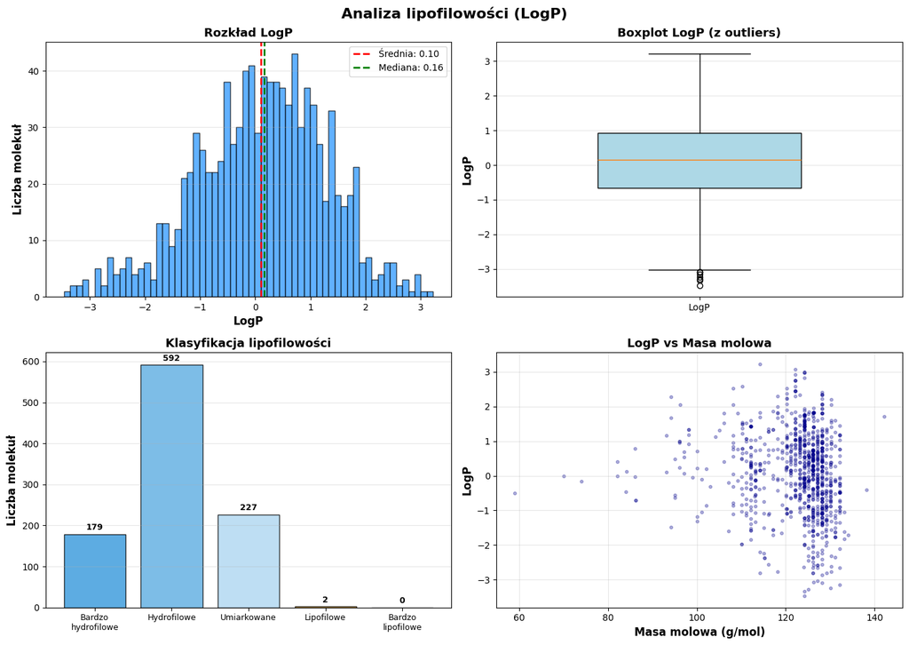

```
======================================================================
🧊 ANALIZA TPSA (TOPOLOGICAL POLAR SURFACE AREA)
======================================================================

📊 Statystyki TPSA:
  • Średnia:    37.80 Ų
  • Mediana:    36.51 Ų
  • Std:        21.40 Ų
  • Max:        112.36 Ų

💊 Drug-likeness (TPSA):
  • BBB permeable (< 140 Ų):    1,000 (100.0%)
  • CNS optimal (< 90 Ų):       991 (99.1%)

✅ Zapisano: qm9_tpsa_analysis.png
```

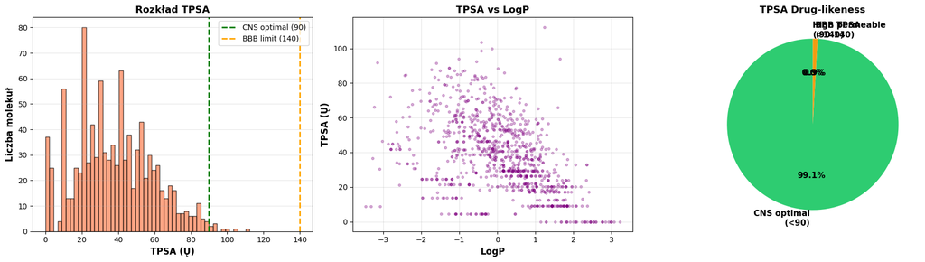

```
======================================================================
🔗 ANALIZA WIĄZAŃ WODOROWYCH (HBD/HBA)
======================================================================

📊 Statystyki:
  • Średnia HBD (donory):     0.97
  • Średnia HBA (akceptory):  2.05
  • Max HBD:                  4
  • Max HBA:                  5

📈 Rozkład HBD:
  0 donorów:   348 (34.80%) ███████████
  1 donorów:   392 (39.20%) █████████████
  2 donorów:   202 (20.20%) ██████
  3 donorów:    56 ( 5.60%) █

📈 Rozkład HBA:
  0 akceptorów:    66 ( 6.60%) ██
  1 akceptorów:   249 (24.90%) ████████
  2 akceptorów:   355 (35.50%) ███████████
  3 akceptorów:   247 (24.70%) ████████
  4 akceptorów:    62 ( 6.20%) ██
  5 akceptorów:    21 ( 2.10%)

✅ Zapisano: qm9_hbond_analysis.png
```

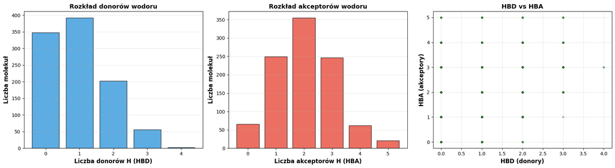

```
======================================================================
💊 REGUŁA LIPIŃSKIEGO (RULE OF 5)
======================================================================

📊 Zgodność z regułą Lipińskiego:
  • Zgodne (≤1 naruszenie):    1,000 (100.0%)
  • Niezgodne (>1 naruszenie): 0 (0.0%)

📈 Rozkład naruszeń:
  0 naruszeń: 1,000 (100.00%) ██████████████████████████████████████████████████

📋 Szczegółowe naruszenia:
  • MW > 500:    0
  • LogP > 5:    0
  • HBD > 5:     0
  • HBA > 10:    0
```

```
✅ Zapisano: qm9_lipinski_ro5.png
```

[figure not shown]

```
======================================================================
🔗 KORELACJE MIĘDZY DESKRYPTORAMI
======================================================================

📊 Najsilniejsze korelacje:

Top 10 najsilniejszych korelacji:
  MolWt                ↔ HeavyAtoms            r = +0.927
  TPSA                 ↔ HBA                   r = +0.821
  LogP                 ↔ HBD                   r = -0.638
  MolMR                ↔ HeavyAtoms            r = +0.578
  TPSA                 ↔ HBD                   r = +0.572
  LogP                 ↔ MolMR                 r = +0.495
  LogP                 ↔ TPSA                  r = -0.476
  MolWt                ↔ MolMR                 r = +0.470
  HBA                  ↔ MolMR                 r = -0.462
  TPSA                 ↔ frac_csp3             r = -0.447

✅ Zapisano: qm9_descriptors_correlation.png
```

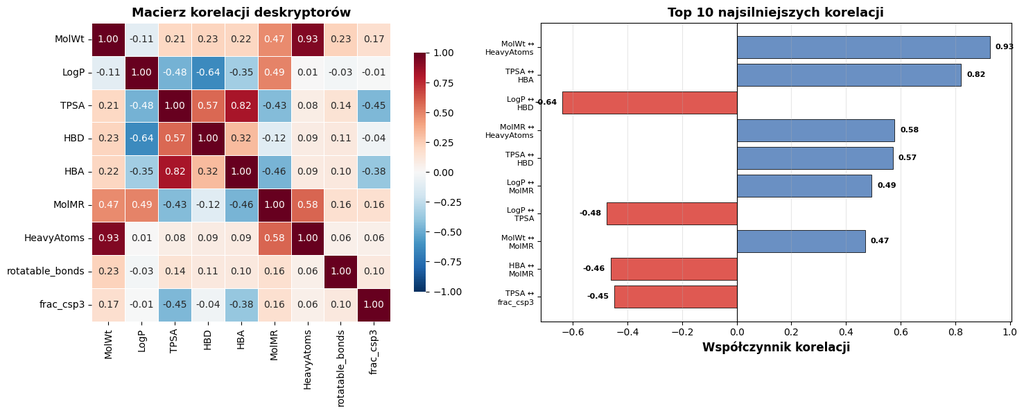

[output not shown]

### 6. WŁAŚCIWOŚCI KWANTOWO-CHEMICZNE ⚛️

- HOMO energy - rozkład, interpretacja
- LUMO energy - rozkład, interpretacja
- HOMO-LUMO gap - kluczowa właściwość, rozkład, outliers
- Dipole moment - polarity molekuł
- Polarizability - odpowiedź na pole elektryczne
- Energy at 0K vs 298K - różnice termodynamiczne
- Heat capacity - właściwości termiczne
- Korelacje między właściwościami kwantowymi

[output not shown]

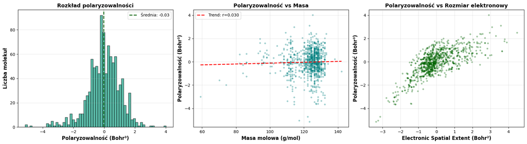

```
======================================================================
🌡️  ANALIZA WŁAŚCIWOŚCI TERMODYNAMICZNYCH
======================================================================

📊 Różnica energii (U298 - U0):
  • Średnia:    0.045818 eV
  • Mediana:    -0.152494 eV
  • Std:        1.715315 eV

📊 Heat Capacity (Cv):
  • Średnia:    0.0286 cal/mol·K
  • Mediana:    -0.0836 cal/mol·K
  • Min:        -3.5388 cal/mol·K
  • Max:        6.6113 cal/mol·K

✅ Zapisano: qm9_thermodynamic_analysis.png
```

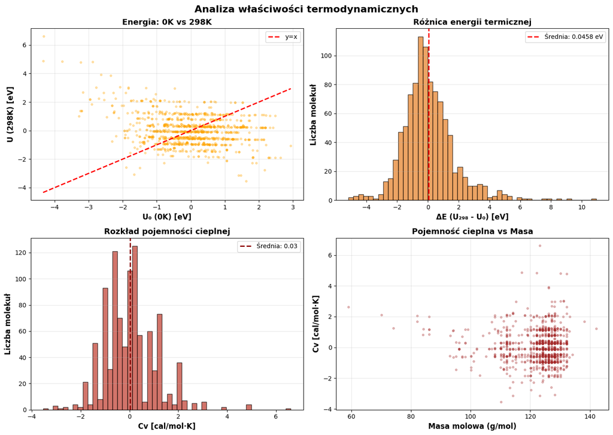

```
======================================================================
🔗 KORELACJE MIĘDZY WŁAŚCIWOŚCIAMI KWANTOWYMI
======================================================================

📊 Najsilniejsze korelacje między właściwościami kwantowymi:

Top 15 najsilniejszych korelacji:
  H                              ↔ G                               r = +1.0000
  U                              ↔ H                               r = +1.0000
  U                              ↔ G                               r = +1.0000
  U                              ↔ Cv                              r = +1.0000
  H                              ↔ Cv                              r = +1.0000
  G                              ↔ Cv                              r = +1.0000
  LUMO                           ↔ gap                             r = +0.8670
  electronic_spatial_extent      ↔ U0                              r = +0.8288
  polarizability                 ↔ U0                              r = +0.7982
  zpve                           ↔ U0                              r = +0.7758
  polarizability                 ↔ zpve                            r = +0.7655
  polarizability                 ↔ electronic_spatial_extent       r = +0.7170
  LUMO                           ↔ zpve                            r = +0.6705
  gap                            ↔ zpve                            r = +0.5705
  electronic_spatial_extent      ↔ zpve                            r = +0.5284

✅ Zapisano: qm9_quantum_correlations.png
```

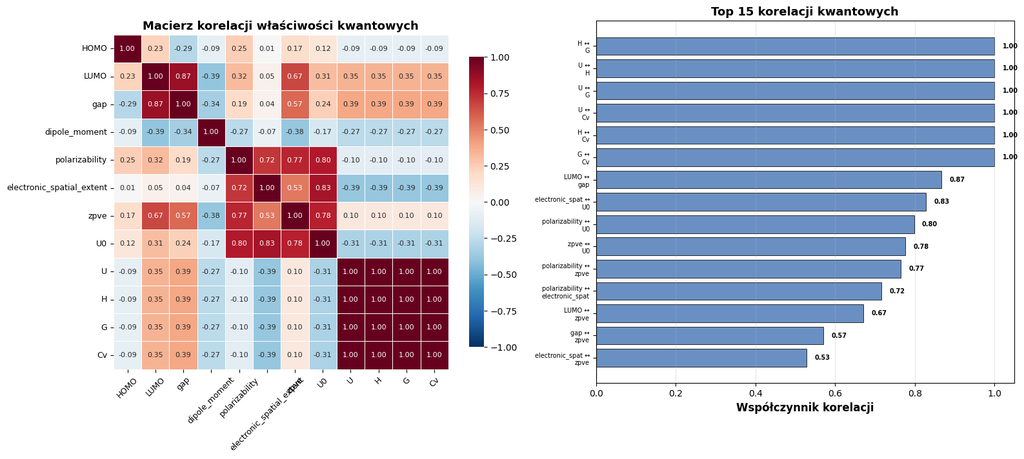

```
======================================================================
📈 KLUCZOWE ZALEŻNOŚCI STRUKTURA-WŁAŚCIWOŚCI
======================================================================

✅ Zapisano: qm9_structure_property_relations.png
```

[figure not shown]

```
======================================================================
📋 PODSUMOWANIE WŁAŚCIWOŚCI KWANTOWO-CHEMICZNYCH
======================================================================
```

[output not shown]

[output cut: 38 more lines]

### 7. ZAAWANSOWANE KORELACJE 📈

- Heatmap korelacji - wszystkie właściwości
- Pairplot - wybrane pary zmiennych
- HOMO vs LUMO - scatter z density
- Gap vs masa molowa - zależność
- Gap vs liczba pierścieni - aromatyczność
- Dipole moment vs TPSA - polarność
- PCA analysis - główne komponenty

```
======================================================================
ZAAWANSOWANE KORELACJE I ANALIZA GŁÓWNYCH KOMPONENTÓW
======================================================================

📊 ETAP 1: KOMPLETNA MACIERZ KORELACJI
----------------------------------------------------------------------

✓ Analizuję 23 właściwości
✓ Macierz korelacji: (23, 23)

✅ Zapisano: qm9_complete_correlation_matrix.png
```

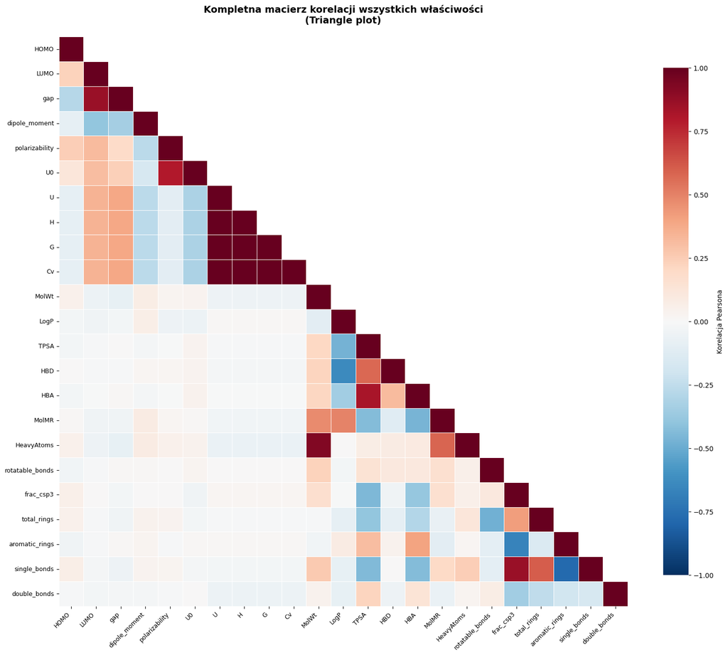

```
🔝 TOP 20 NAJSILNIEJSZYCH KORELACJI (wszystkie właściwości):
  H                         ↔ G                          r = +1.0000
  U                         ↔ H                          r = +1.0000
  U                         ↔ G                          r = +1.0000
  U                         ↔ Cv                         r = +1.0000
  H                         ↔ Cv                         r = +1.0000
  G                         ↔ Cv                         r = +1.0000
  MolWt                     ↔ HeavyAtoms                 r = +0.9272
  LUMO                      ↔ gap                        r = +0.8670
  frac_csp3                 ↔ single_bonds               r = +0.8653
  TPSA                      ↔ HBA                        r = +0.8212
  polarizability            ↔ U0                         r = +0.7982
  aromatic_rings            ↔ single_bonds               r = -0.7747
  frac_csp3                 ↔ aromatic_rings             r = -0.6694
  LogP                      ↔ HBD                        r = -0.6385
  total_rings               ↔ single_bonds               r = +0.6082
  MolMR                     ↔ HeavyAtoms                 r = +0.5782
  TPSA                      ↔ HBD                        r = +0.5720
  LogP                      ↔ MolMR                      r = +0.4946
  rotatable_bonds           ↔ total_rings                r = -0.4823
  LogP                      ↔ TPSA                       r = -0.4764

======================================================================
📊 PAIRPLOT - KLUCZOWE WŁAŚCIWOŚCI
======================================================================

✓ Tworzę pairplot dla 6 zmiennych
   Używam 1000 próbek dla szybkości

✅ Zapisano: qm9_pairplot_key_properties.png
```

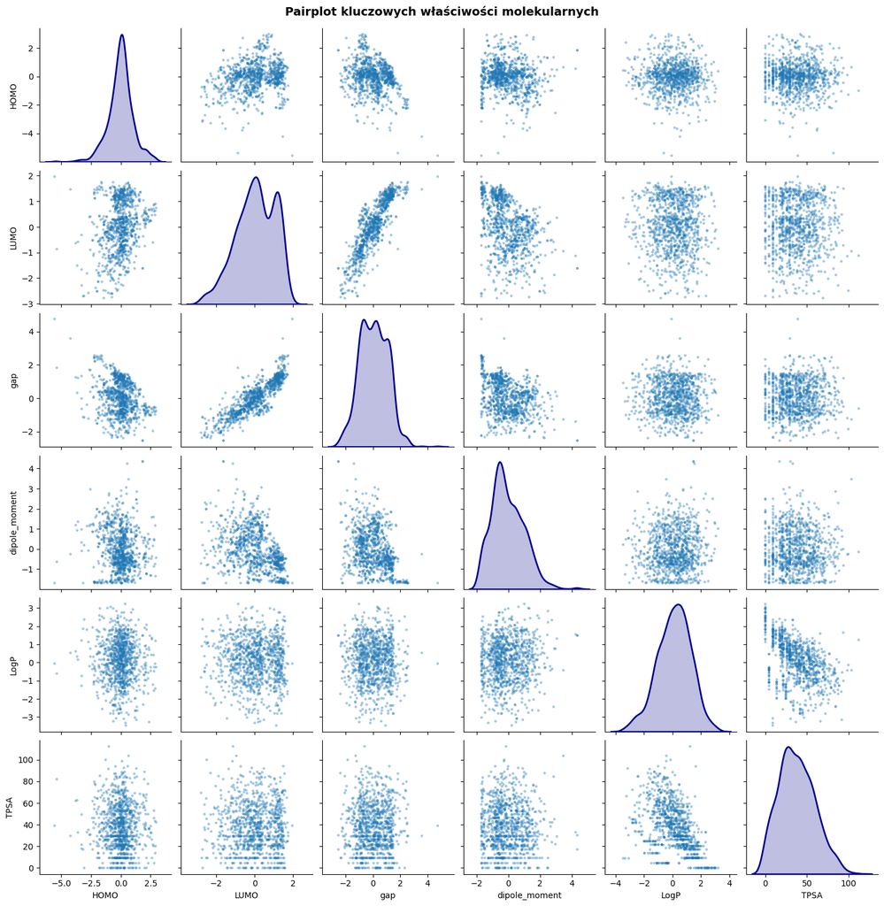

```
======================================================================
🎯 HOMO vs LUMO - SZCZEGÓŁOWA ANALIZA
======================================================================

📊 Korelacja HOMO-LUMO: r = 0.2276
   Regresja: LUMO = 0.2193 × HOMO + 0.0445
   R² = 0.0518, p-value < 0.001

✅ Zapisano: qm9_homo_lumo_detailed.png
```